# 3D Registration

```python
import SimpleITK as sitk
#print(sitk.Version())
import numpy as np
import time
import os
import copy
import importlib

from GetDicomFpaths import GetDicomFpaths

import matplotlib.pyplot as plt
%matplotlib inline

from ipywidgets import interact, fixed
from IPython.display import clear_output

%matplotlib notebook
import gui
import registration_gui as rgui
```

### Define utility functions:

```python
# Define utility functions:
""" Source:
https://github.com/InsightSoftwareConsortium/SimpleITKWorkshopImageJ2015/blob/master/6_Similarity_Metrics_and_Optimization.ipynb
"""

# callback invoked by the interact ipython method for scrolling through the image stacks of
# the two images (moving and fixed)
""" Original: """
def display_images(fixed_image_z, moving_image_z, fixed_npa, moving_npa):
    # create a figure with two subplots and the specified size
    plt.subplots(1,2,figsize=(10,8))

    # draw the fixed image in the first subplot
    plt.subplot(1,2,1)
    plt.imshow(fixed_npa[fixed_image_z,:,:],cmap=plt.cm.Greys_r);
    plt.title('fixed image')
    plt.axis('off')

    # draw the moving image in the second subplot
    plt.subplot(1,2,2)
    plt.imshow(moving_npa[moving_image_z,:,:],cmap=plt.cm.Greys_r);
    plt.title('moving image')
    plt.axis('off')


# callback invoked by the interact ipython method for scrolling through the image stacks of
# the two images (moving and fixed)
""" Slight modification to display_images: Add figure titles as arguments: """
def display_images_v2(fixed_image_z, moving_image_z, fixed_npa, moving_npa, fixed_title, moving_title):
    # Get min, max:
    #fixed_min = np.min(fixed_npa)
    #fixed_max = np.max(fixed_npa)
    #moving_min = np.min(moving_npa)
    #moving_max = np.max(moving_npa)

    # create a figure with two subplots and the specified size
    plt.subplots(1,2,figsize=(10,8))

    # draw the fixed image in the first subplot
    plt.subplot(1,2,1)
    plt.imshow(fixed_npa[fixed_image_z,:,:],cmap=plt.cm.Greys_r);
    #plt.imshow(fixed_npa[fixed_image_z,:,:], cmap=plt.cm.Greys_r, vmin=fixed_min, vmax=fixed_max);
    #plt.imshow(fixed_npa[fixed_image_z,:,:], cmap=plt.cm.Greys_r, norm=True);
    #plt.imshow(fixed_npa[fixed_image_z,:,:], cmap=plt.cm.Greys_r, vmin=0, vmax=255);
    plt.title(fixed_title)
    plt.axis('off')

    # draw the moving image in the second subplot
    plt.subplot(1,2,2)
    plt.imshow(moving_npa[moving_image_z,:,:],cmap=plt.cm.Greys_r);
    #plt.imshow(moving_npa[moving_image_z,:,:], cmap=plt.cm.Greys_r, vmin=moving_min, vmax=moving_max);
    #plt.imshow(moving_npa[moving_image_z,:,:], cmap=plt.cm.Greys_r, norm=True);
    #plt.imshow(moving_npa[moving_image_z,:,:], cmap=plt.cm.Greys_r, vmin=0, vmax=255);
    plt.title(moving_title)
    plt.axis('off')

# callback invoked by the interact ipython method for scrolling through the image stacks of
# the two images (moving and fixed)
""" Slight modification to display_images_v2: Plot registered image as well: """
def display_images_v3(fixed_image_z, moving_image_z, registered_image_z,
                      fixed_npa, moving_npa, registered_npa,
                      fixed_title, moving_title, registered_title):

    # create a figure with two subplots and the specified size
    plt.subplots(1,3,figsize=(9,6))

    # draw the fixed image in the first subplot
    plt.subplot(1,3,1)
    plt.imshow(fixed_npa[fixed_image_z,:,:],cmap=plt.cm.Greys_r);
    plt.title(fixed_title)
    plt.axis('off')

    # draw the moving image in the second subplot
    plt.subplot(1,3,2)
    plt.imshow(moving_npa[moving_image_z,:,:],cmap=plt.cm.Greys_r);
    plt.title(moving_title)
    plt.axis('off')

    # draw the registered image in the third subplot
    plt.subplot(1,3,3)
    plt.imshow(registered_npa[registered_image_z,:,:],cmap=plt.cm.Greys_r);
    plt.title(registered_title)
    plt.axis('off')

# callback invoked by the interact ipython method for scrolling through the image stacks of
# the two images (moving and fixed)
""" Add contours to display_images_v3 """
def display_images_and_contours(fixed_ind, moving_ind, reg_ind,
                                fixed_npa, moving_npa, reg_npa,
                                fixed_im, moving_im, reg_im,
                                fixed_contour_pts,
                                fixed_title, moving_title, reg_title):

    # Get the number of slices in the images:
    fixed_Nslices = fixed_im.GetSize()[2]
    moving_Nslices = moving_im.GetSize()[2]
    reg_Nslices = reg_im.GetSize()[2]

    # Get the z positions of the origins:
    fixed_origin_z = fixed_im.GetOrigin()[2]
    moving_origin_z = moving_im.GetOrigin()[2]
    reg_origin_z = reg_im.GetOrigin()[2]

    # Get the pixel spacings along the z axis:
    fixed_dz = fixed_im.GetSpacing()[2]
    moving_dz = moving_im.GetSpacing()[2]
    reg_dz = reg_im.GetSpacing()[2]

    # Use the z positions of the origins, the pixel spacings along the z axis,
    # and the indeces to get the z positions of the slices in the stacks:
    fixed_zpos = fixed_origin_z + fixed_ind*fixed_dz
    moving_zpos = moving_origin_z + moving_ind*moving_dz
    reg_zpos = reg_origin_z + reg_ind*reg_dz

    # Get the number of contours for this index:
    fixed_Ncontours = len(fixed_contour_pts[fixed_ind])

    print(f'\nFixed slice  {fixed_ind}/{fixed_Nslices}',
          f'at z = {round(fixed_zpos, 2)} mm')
    print(f'Moving slice {moving_ind}/{moving_Nslices}',
          f'at z = {round(moving_zpos, 2)} mm')
    print(f'Reg slice    {reg_ind}/{reg_Nslices}',
          f'at z = {round(reg_zpos, 2)} mm')

    #print(f'\nFixed depth position  {round(fixed_zpos, 2)} mm')
    #print(f'Moving depth position {round(moving_zpos, 2)} mm')
    #print(f'Reg depth position    {round(reg_zpos, 2)} mm')

    print(f'\nFixed no. of contours  = {fixed_Ncontours}')
    #print(f'Moving no. of contours = {fixed_Ncontours}')
    #print(f'Reg no. of contours    = {fixed_Ncontours}')


    # create a figure with two subplots and the specified size
    plt.subplots(1, 3, figsize=(14,5))

    # draw the fixed image in the first subplot
    plt.subplot(1, 3, 1, aspect='equal')
    plt.imshow(fixed_npa[fixed_ind,:,:], cmap=plt.cm.Greys_r);
    #plt.pcolormesh(np.flipud(fixed_npa[fixed_ind,:,:]), cmap=plt.cm.Greys_r);
    plt.title(fixed_title)
    plt.axis('off')

    # Plot contours for fixed image if Npts is not empty:
    if fixed_Ncontours:
        # Unpack tuple and store each x,y tuple in arrays X and Y:
        X = []
        Y = []
        #for x, y, z in fixed_contour_pts[fixed_ind][0]:
        for x, y, z in fixed_contour_pts[fixed_ind]:
            X.append(x)
            Y.append(y)

        # Flip Y pixel coordinates?:
        if False:
            N_r, N_c = np.shape(fixed_npa[fixed_ind,:,:])

            Y = N_c - np.array(Y)

        plt.plot(X, Y, linewidth=0.5, c='red');

    # draw the moving image in the second subplot
    plt.subplot(1, 3, 2, aspect='equal')
    plt.imshow(moving_npa[moving_ind,:,:], cmap=plt.cm.Greys_r);
    #plt.pcolormesh(np.flipud(moving_npa[moving_ind,:,:]), cmap=plt.cm.Greys_r);
    plt.title(moving_title)
    plt.axis('off')

    # draw the registered image in the third subplot
    plt.subplot(1, 3, 3, aspect='equal')
    plt.imshow(reg_npa[reg_ind,:,:], cmap=plt.cm.Greys_r);
    #plt.pcolormesh(np.flipud(reg_npa[reg_ind,:,:]), cmap=plt.cm.Greys_r);
    plt.title(reg_title)
    plt.axis('off')

    # Using reg_inds and fixed_contour_pts, plot contours belonging to the
    # fixed image for the registered image if Npts is not empty:
    if fixed_Ncontours:
        # Unpack tuple and store each x,y tuple in arrays X and Y:
        X = []
        Y = []
        #for x, y, z in fixed_contour_pts[reg_ind][0]:
        for x, y, z in fixed_contour_pts[reg_ind]:
            X.append(x)
            Y.append(y)

        # Flip Y pixel coordinates?:
        if False:
            N_r, N_c = np.shape(reg_npa[reg_ind,:,:])

            Y = N_c - np.array(Y)

        plt.plot(X, Y, linewidth=0.5, c='red');

# callback invoked by the ipython interact method for scrolling and modifying the alpha blending
# of an image stack of two images that occupy the same physical space.
def display_images_with_alpha(image_z, alpha, fixed, moving):
    img = (1.0 - alpha)*fixed[:,:,image_z] + alpha*moving[:,:,image_z]
    plt.imshow(sitk.GetArrayFromImage(img),cmap=plt.cm.Greys_r);
    plt.axis('off')


# callback invoked when the StartEvent happens, sets up our new data
def start_plot():
    global metric_values, multires_iterations

    metric_values = []
    multires_iterations = []

# callback invoked when the EndEvent happens, do cleanup of data and figure
def end_plot():
    global metric_values, multires_iterations

    del metric_values
    del multires_iterations
    #close figure, we don't want to get a duplicate of the plot latter on
    plt.close()

# callback invoked when the IterationEvent happens, update our data and display new figure
def plot_values(registration_method):
    global metric_values, multires_iterations

    metric_values.append(registration_method.GetMetricValue())
    #clear the output area (wait=True, to reduce flickering), and plot current data
    clear_output(wait=True)
    #plot the similarity metric values
    plt.plot(metric_values, 'r')
    plt.plot(multires_iterations, [metric_values[index] for index in multires_iterations], 'b*')
    plt.xlabel('Iteration Number',fontsize=12)
    plt.ylabel('Metric Value',fontsize=12)
    plt.show()

# callback invoked when the sitkMultiResolutionIterationEvent happens, update the index into the
# metric_values list.
def update_multires_iterations():
    global metric_values, multires_iterations
    multires_iterations.append(len(metric_values))


# Plot registration results as was done for DICOM objects (i.e. PlotRegResults()) but for plotting
# of SimpleITK objects:
#def PlotRegResults(FixedImage, MovingImage, RegisteredImage):
#    # Import packages:
#    import SimpleITK as sitk
#
#    # Convert from ITK to Numpy data arrays:
#    FixedImage = sitk.GetArrayFromImage(FixedImage)
#    MovingImage = sitk.GetArrayFromImage(MovingImage)
#    RegisteredImage = sitk.GetArrayFromImage(RegisteredImage)
```

### Define the directories of Fixed and Moving and load the images:

```python
FixedDir = r'C:\Temp\ACRIN_MR_DICOMs'
MovingDir = r'C:\Temp\ACRIN_CT_DICOMs'

SwapFixedMoving = False
#SwapFixedMoving = True

if SwapFixedMoving:
    print('FixedDir and MovingDir swapped.')
else:
    print('FixedDir and MovingDir as originally defined.')

# Read in the 3D stack of Fixed DICOMs:
FixedReader = sitk.ImageSeriesReader()
#FixedReader = sitk.ImageSeriesReader(sitk.sitkFloat32)
if SwapFixedMoving:
    FixedNames = FixedReader.GetGDCMSeriesFileNames(MovingDir)
else:
    FixedNames = FixedReader.GetGDCMSeriesFileNames(FixedDir)
FixedReader.SetFileNames(FixedNames)
FixedIm = FixedReader.Execute()
FixedIm = sitk.Cast(FixedIm, sitk.sitkFloat32)

# Read in the 3D stack of Moving DICOMs:
MovingReader = sitk.ImageSeriesReader()
#MovingReader = sitk.ImageSeriesReader(sitk.sitkFloat32)
if SwapFixedMoving:
    MovingNames = MovingReader.GetGDCMSeriesFileNames(FixedDir)
else:
    MovingNames = MovingReader.GetGDCMSeriesFileNames(MovingDir)
MovingReader.SetFileNames(MovingNames)
MovingIm = MovingReader.Execute()
#MovingIm = MovingReader.Execute(sitk.sitkFloat32)
MovingIm = sitk.Cast(MovingIm, sitk.sitkFloat32)

#FixedDtype = str(FixedIm.dtype)
FixedDtype = FixedIm.GetPixelIDTypeAsString()
#MovingDtype = str(MovingIm.dtype)
MovingDtype = MovingIm.GetPixelIDTypeAsString()
print('\nFixedIm Dtype  =', FixedDtype)
print('MovingIm Dtype =', MovingDtype)

FixedSize = FixedIm.GetSize()
MovingSize = MovingIm.GetSize()
print('\nFixedIm Size  =', FixedSize)
print('MovingIm Size =', MovingSize)

FixedSpacing = FixedIm.GetSpacing()
MovingSpacing = MovingIm.GetSpacing()
print('\nFixedIm Spacing  =', FixedSpacing)
print('MovingIm Spacing =', MovingSpacing)

FixedOrigin = FixedIm.GetOrigin()
MovingOrigin = MovingIm.GetOrigin()
print('\nFixedIm Origin  =', FixedOrigin)
print('MovingIm Origin =', MovingOrigin)

FixedNda = sitk.GetArrayFromImage(FixedIm)
MovingNda = sitk.GetArrayFromImage(MovingIm)
print(f'\nFixedIm Min, Max  = {np.min(FixedNda)}, {np.max(FixedNda)}')
print(f'MovingIm Min, Max = {np.min(MovingNda)}, {np.max(MovingNda)}')
```

```
FixedDir and MovingDir as originally defined.

FixedIm Dtype  = 32-bit float
MovingIm Dtype = 32-bit float

FixedIm Size  = (256, 256, 160)
MovingIm Size = (512, 512, 72)

FixedIm Spacing  = (1.0, 1.0, 1.0)
MovingIm Spacing = (0.423828125, 0.423828125, 2.4130020141601562)

FixedIm Origin  = (-134.53753662109375, -167.07070922851562, -79.45004272460938)
MovingIm Origin = (-108.2880859375, -282.97186279296875, 115.51118469238281)

FixedIm Min, Max  = 0.0, 448.0
MovingIm Min, Max = -1024.0, 3071.0
```

### First tried using sitk.JoinSeries(FixedVectorOfImages) and sitk.JoinSeries(MovingVectorOfImages) but not sure JoinSeries is appropriate to use here...

```python
# Use GetDicomFpaths to get list of Fixed and Moving filepaths.
FixedFpaths = GetDicomFpaths(FixedDir, 'slices', Debug=False)
MovingFpaths = GetDicomFpaths(MovingDir, 'slices', Debug=False)


# Start timing:
times = []
times.append(time.time())

# Concatenate the 2D images into one 3D image:
FixedVectorOfImages = sitk.VectorOfImage()
MovingVectorOfImages = sitk.VectorOfImage()

times.append(time.time())
Dtime = round(times[-1] - times[-2], 1)
print(f'\nTook {Dtime} s to concatenate the 2D images.')

for fpath in FixedFpaths:
    FixedVectorOfImages.push_back(sitk.ReadImage(fpath))

times.append(time.time())
Dtime = round(times[-1] - times[-2], 1)
print(f'\nTook {Dtime} s to read the Fixed 3D image stack.')

for fpath in MovingFpaths:
    MovingVectorOfImages.push_back(sitk.ReadImage(fpath))

times.append(time.time())
Dtime = round(times[-1] - times[-2], 1)
print(f'\nTook {Dtime} s to read the Moving 3D image stack.')

FixedIm = sitk.JoinSeries(FixedVectorOfImages)
MovingIm = sitk.JoinSeries(MovingVectorOfImages)

# Register the 3D images:
ImFilter = sitk.ElastixImageFilter()
ImFilter.LogToConsoleOn()
ImFilter.LogToFileOn()
ImFilter.SetFixedImage(FixedIm)
ImFilter.SetMovingImage(MovingIm)
ImFilter.SetParameterMap(sitk.GetDefaultParameterMap('groupwise'))

times.append(time.time())
Dtime = round(times[-1] - times[-2], 1)
print(f'\nTook {Dtime} s to register the 3D image stacks.')
```

```
Took 0.0 s to concatenate the 2D images.

Took 0.7 s to read the Fixed 3D image stack.

Took 0.5 s to read the Moving 3D image stack.
```

```
---------------------------------------------------------------------------
RuntimeError                              Traceback (most recent call last)
<ipython-input-3-15a75ca90ca8> in <module>
     30 print(f'\nTook {Dtime} s to read the Moving 3D image stack.')
     31
---> 32 FixedIm = sitk.JoinSeries(FixedVectorOfImages)
     33 MovingIm = sitk.JoinSeries(MovingVectorOfImages)
     34

~\Anaconda37\lib\site-packages\simpleitk-1.2.0rc2.dev1162+g2a79d-py3.7-win-amd64.egg\SimpleITK\SimpleITK.py in JoinSeries(*args)
  41010     JoinSeries(Image image1, Image image2, Image image3, Image image4, Image image5, double origin=0.0, double spacing=1.0) -> Image
  41011     """
> 41012     return _SimpleITK.JoinSeries(*args)
  41013 class KittlerIllingworthThresholdImageFilter(ImageFilter_0):
  41014     """

RuntimeError: Exception thrown in SimpleITK JoinSeries: C:\SimpleElastix\build_20200108\ITK-prefix\include\ITK-4.13\itkImageToImageFilter.hxx:241:
itk::ERROR: JoinSeriesImageFilter(0000026706945590): Inputs do not occupy the same physical space!
InputImage Origin: [-1.3453753e+02, -1.6707071e+02, -7.9450044e+01], InputImage_1 Origin: [-1.3453753e+02, -1.6707071e+02, -7.8450044e+01]
	Tolerance: 1.0000000e-06
```

### Try registering a stack to itself to see if anything can be made to work:

```python
# Start timing:
times = []
times.append(time.time())

FixedIm = sitk.JoinSeries(FixedVectorOfImages)
#MovingIm = sitk.JoinSeries(MovingVectorOfImages)

# Register the 3D images:
ImFilter = sitk.ElastixImageFilter()
ImFilter.LogToConsoleOn()
ImFilter.LogToFileOn()
ImFilter.SetFixedImage(FixedIm)
#ImFilter.SetMovingImage(MovingIm)
ImFilter.SetMovingImage(FixedIm)
ImFilter.SetParameterMap(sitk.GetDefaultParameterMap('groupwise'))

times.append(time.time())
Dtime = round(times[-1] - times[-2], 1)
print(f'\nTook {Dtime} s to register the 3D image stacks.')
```

```
---------------------------------------------------------------------------
RuntimeError                              Traceback (most recent call last)
<ipython-input-39-4dacc38d0726> in <module>
      3 times.append(time.time())
      4
----> 5 FixedIm = sitk.JoinSeries(FixedVectorOfImages)
      6 #MovingIm = sitk.JoinSeries(MovingVectorOfImages)
      7

~\Anaconda37\lib\site-packages\simpleitk-1.2.0rc2.dev1162+g2a79d-py3.7-win-amd64.egg\SimpleITK\SimpleITK.py in JoinSeries(*args)
  41010     JoinSeries(Image image1, Image image2, Image image3, Image image4, Image image5, double origin=0.0, double spacing=1.0) -> Image
  41011     """
> 41012     return _SimpleITK.JoinSeries(*args)
  41013 class KittlerIllingworthThresholdImageFilter(ImageFilter_0):
  41014     """

RuntimeError: Exception thrown in SimpleITK JoinSeries: C:\SimpleElastix\build_20200108\ITK-prefix\include\ITK-4.13\itkImageToImageFilter.hxx:241:
itk::ERROR: JoinSeriesImageFilter(000001A845E47180): Inputs do not occupy the same physical space!
InputImage Origin: [-1.3453753e+02, -1.6707071e+02, -7.9450044e+01], InputImage_1 Origin: [-1.3453753e+02, -1.6707071e+02, -7.8450044e+01]
	Tolerance: 1.0000000e-06
```

### The error "Inputs do not occupy the same physical space" suggests to me that JoinSeries() is meant to be used to align a series of images of similar physical content - not for a stack of images that correspond to completely different images as is the case in a 3D scan.

### This time use ImageSeriesReader():

```python
SwapFixedMoving = False
#SwapFixedMoving = True

FixedReader = sitk.ImageSeriesReader()
if SwapFixedMoving:
    FixedNames = FixedReader.GetGDCMSeriesFileNames(MovingDir)
else:
    FixedNames = FixedReader.GetGDCMSeriesFileNames(FixedDir)
FixedReader.SetFileNames(FixedNames)
FixedIm = FixedReader.Execute()

MovingReader = sitk.ImageSeriesReader()
if SwapFixedMoving:
    MovingNames = MovingReader.GetGDCMSeriesFileNames(FixedDir)
else:
    MovingNames = MovingReader.GetGDCMSeriesFileNames(MovingDir)
MovingReader.SetFileNames(MovingNames)
MovingIm = MovingReader.Execute()

FixedSize = FixedIm.GetSize()
MovingSize = MovingIm.GetSize()
print('\nFixedIm Size  =', FixedSize)
print('MovingIm Size =', MovingSize)

FixedOrigin = FixedIm.GetOrigin()
MovingOrigin = MovingIm.GetOrigin()
print('\nFixedIm Origin  =', FixedOrigin)
print('MovingIm Origin =', MovingOrigin)

FixedSpacing = FixedIm.GetSpacing()
MovingSpacing = MovingIm.GetSpacing()
print('\nFixedIm Spacing  =', FixedSpacing)
print('MovingIm Spacing =', MovingSpacing)


# Start timing:
times = []
times.append(time.time())

# Register the 3D images:
ImFilter = sitk.ElastixImageFilter()
ImFilter.SetFixedImage(FixedIm)
ImFilter.SetMovingImage(MovingIm)
#ImFilter.SetMovingImage(FixedIm)
#ImFilter.SetParameterMap(sitk.GetDefaultParameterMap('groupwise'))
ImFilter.SetParameterMap(sitk.GetDefaultParameterMap('affine'))
ImFilter.LogToConsoleOn()
ImFilter.LogToFileOn()
RegIm = ImFilter.Execute()

times.append(time.time())
Dtime = round(times[-1] - times[-2], 1)
print(f'\nTook {Dtime} s to register the 3D image stacks.')
```

```
FixedIm Size  = (256, 256, 160)
MovingIm Size = (512, 512, 72)

FixedIm Origin  = (-134.53753662109375, -167.07070922851562, -79.45004272460938)
MovingIm Origin = (-108.2880859375, -282.97186279296875, 115.51118469238281)

FixedIm Spacing  = (1.0, 1.0, 1.0)
MovingIm Spacing = (0.423828125, 0.423828125, 2.4130020141601562)
```

[output not shown]

### See elastix_20200506_0843.log for more details:

itk::ExceptionObject (00000099665E7978)

Location: "ElastixTemplate - Run()"

File: C:\SimpleElastix\build_20200108\Elastix\Common\CostFunctions\itkAdvancedImageToImageMetric.hxx

Line: 1005

Description: itk::ERROR: AdvancedMattesMutualInformationMetric(000002670EFF89F0): Too many samples map outside moving image buffer: 0 / 4332

Error occurred during actual registration.

### See comment by salan668 here:

https://github.com/SuperElastix/SimpleElastix/issues/132

"Here the fixed image was a 3D high-resolution image and moving image was a 3D low-resolution image. I found that if the fixed image and the moving image has similar resolution, SimpleElastix works. But if resolutions are different from each other, this error appears."

### Try reversing FixedIm and MovingIm:

```python
#SwapFixedMoving = False
SwapFixedMoving = True

FixedReader = sitk.ImageSeriesReader()
if SwapFixedMoving:
    FixedNames = FixedReader.GetGDCMSeriesFileNames(MovingDir)
else:
    FixedNames = FixedReader.GetGDCMSeriesFileNames(FixedDir)
FixedReader.SetFileNames(FixedNames)
FixedIm = FixedReader.Execute()

MovingReader = sitk.ImageSeriesReader()
if SwapFixedMoving:
    MovingNames = MovingReader.GetGDCMSeriesFileNames(FixedDir)
else:
    MovingNames = MovingReader.GetGDCMSeriesFileNames(MovingDir)
MovingReader.SetFileNames(MovingNames)
MovingIm = MovingReader.Execute()

FixedSize = FixedIm.GetSize()
MovingSize = MovingIm.GetSize()
print('\nFixedIm Size  =', FixedSize)
print('MovingIm Size =', MovingSize)

FixedOrigin = FixedIm.GetOrigin()
MovingOrigin = MovingIm.GetOrigin()
print('\nFixedIm Origin  =', FixedOrigin)
print('MovingIm Origin =', MovingOrigin)

FixedSpacing = FixedIm.GetSpacing()
MovingSpacing = MovingIm.GetSpacing()
print('\nFixedIm Spacing  =', FixedSpacing)
print('MovingIm Spacing =', MovingSpacing)


# Start timing:
times = []
times.append(time.time())

# Register the 3D images:
ImFilter = sitk.ElastixImageFilter()
ImFilter.SetFixedImage(FixedIm)
ImFilter.SetMovingImage(MovingIm)
#ImFilter.SetMovingImage(FixedIm)
#ImFilter.SetParameterMap(sitk.GetDefaultParameterMap('groupwise'))
ImFilter.SetParameterMap(sitk.GetDefaultParameterMap('affine'))
ImFilter.LogToConsoleOn()
ImFilter.LogToFileOn()
RegIm3D = ImFilter.Execute()

times.append(time.time())
Dtime = round(times[-1] - times[-2], 1)
print(f'\nTook {Dtime} s to register the 3D image stacks.')
```

```
FixedIm Size  = (512, 512, 72)
MovingIm Size = (256, 256, 160)

FixedIm Origin  = (-108.2880859375, -282.97186279296875, 115.51118469238281)
MovingIm Origin = (-134.53753662109375, -167.07070922851562, -79.45004272460938)

FixedIm Spacing  = (0.423828125, 0.423828125, 2.4130020141601562)
MovingIm Spacing = (1.0, 1.0, 1.0)
```

```
---------------------------------------------------------------------------
RuntimeError                              Traceback (most recent call last)
<ipython-input-3-e9f22c7e475d> in <module>
     47 ImFilter.LogToConsoleOn()
     48 ImFilter.LogToFileOn()
---> 49 RegIm3D = ImFilter.Execute()
     50
     51 times.append(time.time())

~\Anaconda37\lib\site-packages\simpleitk-1.2.0rc2.dev1162+g2a79d-py3.7-win-amd64.egg\SimpleITK\SimpleITK.py in Execute(self)
  10994     def Execute(self):
  10995         """Execute(ElastixImageFilter self) -> Image"""
> 10996         return _SimpleITK.ElastixImageFilter_Execute(self)
  10997
  10998

RuntimeError: Exception thrown in SimpleITK ElastixImageFilter_Execute: C:\SimpleElastix\source\SimpleElastix\Code\Elastix\src\sitkElastixImageFilterImpl.cxx:259:
sitk::ERROR:
itk::ExceptionObject (0000000F06BE7A70)
Location: "unknown"
File: C:\SimpleElastix\build_20200108\Elastix\Core\Main\elxElastixFilter.hxx
Line: 253
Description: itk::ERROR: Self(0000018241DBE120): Internal elastix error: See elastix log (use LogToConsoleOn() or LogToFileOn()).
```

### Same error as before - see elastix_20200506_0955.log for more details:

itk::ExceptionObject (0000000F06BE75E8)

Location: "ElastixTemplate - Run()"

File: C:\SimpleElastix\build_20200108\Elastix\Common\CostFunctions\itkAdvancedImageToImageMetric.hxx

Line: 1005

Description: itk::ERROR: AdvancedMattesMutualInformationMetric(0000018241DBEE20): Too many samples map outside moving image buffer: 0 / 4805

Error occurred during actual registration.

### Try setting some additional distance metrics following the thread:

### https://github.com/SuperElastix/SimpleElastix/issues/70

### 06/05/2020: Although part of the error code is the same ("Location unknown") I think this error might be unrelated to the error I got.

```python
# Read in the 3D stack of Fixed DICOMs:
FixedReader = sitk.ImageSeriesReader()
FixedNames = FixedReader.GetGDCMSeriesFileNames(FixedDir)
FixedReader.SetFileNames(FixedNames)
FixedIm = FixedReader.Execute()

# Read in the 3D stack of Moving DICOMs:
MovingReader = sitk.ImageSeriesReader()
MovingNames = MovingReader.GetGDCMSeriesFileNames(MovingDir)
MovingReader.SetFileNames(MovingNames)
MovingIm = MovingReader.Execute()

# Start timing:
times = []
times.append(time.time())

# Register the 3D images:
ImFilter = sitk.ElastixImageFilter()
ImFilter.LogToConsoleOn()
ImFilter.LogToFileOn()
"""
Setting some additional parameters following the thread:
https://github.com/SuperElastix/SimpleElastix/issues/70
"""
ImFilter.SetParameter( "Metric", "CorrespondingPointsEuclideanDistanceMetric" )
ImFilter.SetParameter( "Metric", ("NormalizedMutualInformation", "CorrespondingPointsEuclideanDistanceMetric",))
ImFilter.SetParameter("Metric0Weight", "0.0")
ImFilter.SetFixedImage(FixedIm)
ImFilter.SetMovingImage(MovingIm)
ImFilter.SetParameterMap(sitk.GetDefaultParameterMap('affine'))
RegIm = ImFilter.Execute()

times.append(time.time())
Dtime = round(times[-1] - times[-2], 1)
print(f'\nTook {Dtime} s to register the 3D image stacks.')
```

```
---------------------------------------------------------------------------
RuntimeError                              Traceback (most recent call last)
<ipython-input-41-b167822aa80e> in <module>
     29 ImFilter.SetMovingImage(MovingIm)
     30 ImFilter.SetParameterMap(sitk.GetDefaultParameterMap('affine'))
---> 31 RegIm = ImFilter.Execute()
     32
     33 times.append(time.time())

~\Anaconda37\lib\site-packages\simpleitk-1.2.0rc2.dev1162+g2a79d-py3.7-win-amd64.egg\SimpleITK\SimpleITK.py in Execute(self)
  10994     def Execute(self):
  10995         """Execute(ElastixImageFilter self) -> Image"""
> 10996         return _SimpleITK.ElastixImageFilter_Execute(self)
  10997
  10998

RuntimeError: Exception thrown in SimpleITK ElastixImageFilter_Execute: C:\SimpleElastix\source\SimpleElastix\Code\Elastix\src\sitkElastixImageFilterImpl.cxx:259:
sitk::ERROR:
itk::ExceptionObject (0000007B3E5E79E0)
Location: "unknown"
File: C:\SimpleElastix\build_20200108\Elastix\Core\Main\elxElastixFilter.hxx
Line: 253
Description: itk::ERROR: Self(000001A83CC016E0): Internal elastix error: See elastix log (use LogToConsoleOn() or LogToFileOn()).
```

### Same as above but setting the fixed and moving images to be the same:

```python
# Start timing:
times = []
times.append(time.time())

# Register the 3D images:
ImFilter = sitk.ElastixImageFilter()
ImFilter.LogToConsoleOn()
ImFilter.LogToFileOn()
"""
Setting some additional parameters following the thread:
https://github.com/SuperElastix/SimpleElastix/issues/70
"""
ImFilter.SetParameter( "Metric", "CorrespondingPointsEuclideanDistanceMetric" )
ImFilter.SetParameter( "Metric", ("NormalizedMutualInformation", "CorrespondingPointsEuclideanDistanceMetric",))
ImFilter.SetParameter("Metric0Weight", "0.0")
ImFilter.SetFixedImage(FixedIm)
#ImFilter.SetMovingImage(MovingIm)
ImFilter.SetMovingImage(FixedIm) # <-- SetMovingImage = FixedIm
ImFilter.SetParameterMap(sitk.GetDefaultParameterMap('affine'))
RegIm = ImFilter.Execute()

times.append(time.time())
Dtime = round(times[-1] - times[-2], 1)
print(f'\nTook {Dtime} s to register the 3D image stacks.')
```

```
Took 12.5 s to register the 3D image stacks.
```

### So performing a self registration worked. This is consistent with salan668's comment.

### Next try setting AutomaticTransformInitializationMethod as in section 5.5.2 in the manual:

### Also see comment by kaspermasrstal on 01/22/2018 here:

### https://github.com/SuperElastix/SimpleElastix/issues/152

#### "No, this is because the images do not overlap in the world coordinate system. You can try to enable automatric transform initialization by setting "AutomaticTransformInitialization" to "true". "

```python
# Read in the 3D stack of Fixed DICOMs:
FixedReader = sitk.ImageSeriesReader()
FixedNames = FixedReader.GetGDCMSeriesFileNames(FixedDir)
FixedReader.SetFileNames(FixedNames)
FixedIm = FixedReader.Execute()

# Read in the 3D stack of Moving DICOMs:
MovingReader = sitk.ImageSeriesReader()
MovingNames = MovingReader.GetGDCMSeriesFileNames(MovingDir)
MovingReader.SetFileNames(MovingNames)
MovingIm = MovingReader.Execute()

# Start timing:
times = []
times.append(time.time())

# Register the 3D images:
ImFilter = sitk.ElastixImageFilter()
ImFilter.LogToConsoleOn()
ImFilter.LogToFileOn()
"""
Setting some additional parameters from section 5.5.2 in the manual:
"""
ImFilter.SetParameter( "AutomaticTransformInitializationMethod", "GeometricalCenter" )
ImFilter.SetFixedImage(FixedIm)
ImFilter.SetMovingImage(MovingIm)
ImFilter.SetParameterMap(sitk.GetDefaultParameterMap('affine'))
RegIm = ImFilter.Execute()

times.append(time.time())
Dtime = round(times[-1] - times[-2], 1)
print(f'\nTook {Dtime} s to register the 3D image stacks.')
```

```
---------------------------------------------------------------------------
RuntimeError                              Traceback (most recent call last)
<ipython-input-3-cccd379dce1f> in <module>
     26 ImFilter.SetMovingImage(MovingIm)
     27 ImFilter.SetParameterMap(sitk.GetDefaultParameterMap('affine'))
---> 28 RegIm = ImFilter.Execute()
     29
     30 times.append(time.time())

~\Anaconda37\lib\site-packages\simpleitk-1.2.0rc2.dev1162+g2a79d-py3.7-win-amd64.egg\SimpleITK\SimpleITK.py in Execute(self)
  10994     def Execute(self):
  10995         """Execute(ElastixImageFilter self) -> Image"""
> 10996         return _SimpleITK.ElastixImageFilter_Execute(self)
  10997
  10998

RuntimeError: Exception thrown in SimpleITK ElastixImageFilter_Execute: C:\SimpleElastix\source\SimpleElastix\Code\Elastix\src\sitkElastixImageFilterImpl.cxx:259:
sitk::ERROR:
itk::ExceptionObject (00000084C4BE7820)
Location: "unknown"
File: C:\SimpleElastix\build_20200108\Elastix\Core\Main\elxElastixFilter.hxx
Line: 253
Description: itk::ERROR: Self(000001CD3C3C3B40): Internal elastix error: See elastix log (use LogToConsoleOn() or LogToFileOn()).
```

### See error log elastix_20200507_0956.log for details:

#### itk::ExceptionObject (00000084C4BE7398)

#### Location: "ElastixTemplate - Run()"

#### File: C:\SimpleElastix\build_20200108\Elastix\Common\CostFunctions\itkAdvancedImageToImageMetric.hxx

#### Line: 1005

#### Description: itk::ERROR: AdvancedMattesMutualInformationMetric(000001CD3C8E1BD0): Too many samples map outside moving image buffer: 0 / 4332

#### Error occurred during actual registration.

### Repeat above but perform registration of FixedIm3D to itself:

```python
# Start timing:
times = []
times.append(time.time())

# Register the 3D images:
ImFilter = sitk.ElastixImageFilter()
ImFilter.LogToConsoleOn()
ImFilter.LogToFileOn()
"""
Setting some additional parameters from section 5.5.2 in the manual:
"""
ImFilter.SetParameter( "AutomaticTransformInitializationMethod", "GeometricalCenter" )
ImFilter.SetFixedImage(FixedIm)
#ImFilter.SetMovingImage(MovingIm)
ImFilter.SetMovingImage(FixedIm) # <-- SetMovingImage = FixedIm
ImFilter.SetParameterMap(sitk.GetDefaultParameterMap('affine'))
RegIm = ImFilter.Execute()

times.append(time.time())
Dtime = round(times[-1] - times[-2], 1)
print(f'\nTook {Dtime} s to register the 3D image stacks.')

RegSize = RegIm.GetSize()
print('\nRegIm Size  =', RegSize)

RegOrigin = RegIm.GetOrigin()
print('\nRegIm Origin  =', RegOrigin)

RegSpacing = RegIm.GetSpacing()
print('\nRegIm Spacing  =', RegSpacing)
```

```
Took 13.8 s to register the 3D image stacks.

RegIm Size  = (256, 256, 160)

RegIm Origin  = (-134.53753662109375, -167.07070922851562, -79.45004272460938)

RegIm Spacing  = (1.0, 1.0, 1.0)
```

### So performing a self-registration worked.

### Next try reversing the Fixed and Moving stack as in the following:

### https://groups.google.com/forum/#!category-topic/elastix-imageregistration/simpleelastix/HPVGTR5V6cQ

```python
SwapFixedMoving = False
#SwapFixedMoving = True

if SwapFixedMoving:
    print('FixedDir and MovingDir swapped.')
else:
    print('FixedDir and MovingDir as originally defined.')

# Read in the 3D stack of Fixed DICOMs:
FixedReader = sitk.ImageSeriesReader()
#FixedReader = sitk.ImageSeriesReader(sitk.sitkFloat32)
if SwapFixedMoving:
    FixedNames = FixedReader.GetGDCMSeriesFileNames(MovingDir)
else:
    FixedNames = FixedReader.GetGDCMSeriesFileNames(FixedDir)
FixedReader.SetFileNames(FixedNames)
FixedIm = FixedReader.Execute()
FixedIm = sitk.Cast(FixedIm, sitk.sitkFloat32)

# Read in the 3D stack of Moving DICOMs:
MovingReader = sitk.ImageSeriesReader()
#MovingReader = sitk.ImageSeriesReader(sitk.sitkFloat32)
if SwapFixedMoving:
    MovingNames = MovingReader.GetGDCMSeriesFileNames(FixedDir)
else:
    MovingNames = MovingReader.GetGDCMSeriesFileNames(MovingDir)
MovingReader.SetFileNames(MovingNames)
MovingIm = MovingReader.Execute()
#MovingIm = MovingReader.Execute(sitk.sitkFloat32)
MovingIm = sitk.Cast(MovingIm, sitk.sitkFloat32)

#FixedDtype = str(FixedIm.dtype)
FixedDtype = FixedIm.GetPixelIDTypeAsString()
#MovingDtype = str(MovingIm.dtype)
MovingDtype = MovingIm.GetPixelIDTypeAsString()
print('\nFixedIm Dtype  =', FixedDtype)
print('MovingIm Dtype =', MovingDtype)

FixedSize = FixedIm.GetSize()
MovingSize = MovingIm.GetSize()
print('\nFixedIm Size  =', FixedSize)
print('MovingIm Size =', MovingSize)

FixedSpacing = FixedIm.GetSpacing()
MovingSpacing = MovingIm.GetSpacing()
print('\nFixedIm Spacing  =', FixedSpacing)
print('MovingIm Spacing =', MovingSpacing)

FixedOrigin = FixedIm.GetOrigin()
MovingOrigin = MovingIm.GetOrigin()
print('\nFixedIm Origin  =', FixedOrigin)
print('MovingIm Origin =', MovingOrigin)

# Start timing:
times = []
times.append(time.time())

# Register the 3D images:
ImFilter = sitk.ElastixImageFilter()
ImFilter.LogToConsoleOn()
ImFilter.LogToFileOn()
"""
Setting some additional parameters from section 5.5.2 in the manual:
"""
ImFilter.SetParameter( "AutomaticTransformInitializationMethod", "GeometricalCenter" )
ImFilter.SetFixedImage(FixedIm)
ImFilter.SetMovingImage(MovingIm)
ImFilter.SetParameterMap(sitk.GetDefaultParameterMap('affine'))
RegIm = ImFilter.Execute()

times.append(time.time())
Dtime = round(times[-1] - times[-2], 1)
print(f'\nTook {Dtime} s to register the 3D image stacks.')

RegSize = RegIm.GetSize()
print('\nRegIm Size  =', RegSize)

RegSpacing = RegIm.GetSpacing()
print('\nRegIm Spacing  =', RegSpacing)

RegOrigin = RegIm.GetOrigin()
print('\nRegIm Origin  =', RegOrigin)
```

```
FixedDir and MovingDir as originally defined.

FixedIm Dtype  = 32-bit float
MovingIm Dtype = 32-bit float

FixedIm Size  = (256, 256, 160)
MovingIm Size = (512, 512, 72)

FixedIm Spacing  = (1.0, 1.0, 1.0)
MovingIm Spacing = (0.423828125, 0.423828125, 2.4130020141601562)

FixedIm Origin  = (-134.53753662109375, -167.07070922851562, -79.45004272460938)
MovingIm Origin = (-108.2880859375, -282.97186279296875, 115.51118469238281)
```

```
---------------------------------------------------------------------------
RuntimeError                              Traceback (most recent call last)
<ipython-input-45-9c109baf1f8c> in <module>
     67 ImFilter.SetMovingImage(MovingIm)
     68 ImFilter.SetParameterMap(sitk.GetDefaultParameterMap('affine'))
---> 69 RegIm = ImFilter.Execute()
     70
     71 times.append(time.time())

~\Anaconda37\lib\site-packages\simpleitk-1.2.0rc2.dev1162+g2a79d-py3.7-win-amd64.egg\SimpleITK\SimpleITK.py in Execute(self)
  10994     def Execute(self):
  10995         """Execute(ElastixImageFilter self) -> Image"""
> 10996         return _SimpleITK.ElastixImageFilter_Execute(self)
  10997
  10998

RuntimeError: Exception thrown in SimpleITK ElastixImageFilter_Execute: C:\SimpleElastix\source\SimpleElastix\Code\Elastix\src\sitkElastixImageFilterImpl.cxx:259:
sitk::ERROR:
itk::ExceptionObject (0000007B3E5E79E0)
Location: "unknown"
File: C:\SimpleElastix\build_20200108\Elastix\Core\Main\elxElastixFilter.hxx
Line: 253
Description: itk::ERROR: Self(000001A83CC01540): Internal elastix error: See elastix log (use LogToConsoleOn() or LogToFileOn()).
```

### That didn't help, even after casting to float32. It seems that without knowing how to resolve the issue that SimpleElastix has with registrations of unequal resolutions it won't be possible to progress. So will move onto SimpleITK framework instead.

### April 30:

### Try following the example shown in this tutorial:

### https://github.com/InsightSoftwareConsortium/SimpleITKWorkshopImageJ2015/blob/master/6_Similarity_Metrics_and_Optimization.ipynb

```python
# Define utility functions:

# These were moved to the top.
"""
import matplotlib.pyplot as plt
%matplotlib inline

from ipywidgets import interact, fixed
from IPython.display import clear_output

# callback invoked by the interact ipython method for scrolling through the image stacks of
# the two images (moving and fixed)
def display_images(fixed_image_z, moving_image_z, fixed_npa, moving_npa):
    # create a figure with two subplots and the specified size
    plt.subplots(1,2,figsize=(10,8))

    # draw the fixed image in the first subplot
    plt.subplot(1,2,1)
    plt.imshow(fixed_npa[fixed_image_z,:,:],cmap=plt.cm.Greys_r);
    plt.title('fixed image')
    plt.axis('off')

    # draw the moving image in the second subplot
    plt.subplot(1,2,2)
    plt.imshow(moving_npa[moving_image_z,:,:],cmap=plt.cm.Greys_r);
    plt.title('moving image')
    plt.axis('off')

# callback invoked by the ipython interact method for scrolling and modifying the alpha blending
# of an image stack of two images that occupy the same physical space.
def display_images_with_alpha(image_z, alpha, fixed, moving):
    img = (1.0 - alpha)*fixed[:,:,image_z] + alpha*moving[:,:,image_z]
    plt.imshow(sitk.GetArrayFromImage(img),cmap=plt.cm.Greys_r);
    plt.axis('off')


# callback invoked when the StartEvent happens, sets up our new data
def start_plot():
    global metric_values, multires_iterations

    metric_values = []
    multires_iterations = []

# callback invoked when the EndEvent happens, do cleanup of data and figure
def end_plot():
    global metric_values, multires_iterations

    del metric_values
    del multires_iterations
    #close figure, we don't want to get a duplicate of the plot latter on
    plt.close()

# callback invoked when the IterationEvent happens, update our data and display new figure
def plot_values(registration_method):
    global metric_values, multires_iterations

    metric_values.append(registration_method.GetMetricValue())
    #clear the output area (wait=True, to reduce flickering), and plot current data
    clear_output(wait=True)
    #plot the similarity metric values
    plt.plot(metric_values, 'r')
    plt.plot(multires_iterations, [metric_values[index] for index in multires_iterations], 'b*')
    plt.xlabel('Iteration Number',fontsize=12)
    plt.ylabel('Metric Value',fontsize=12)
    plt.show()

# callback invoked when the sitkMultiResolutionIterationEvent happens, update the index into the
# metric_values list.
def update_multires_iterations():
    global metric_values, multires_iterations
    multires_iterations.append(len(metric_values))
"""
```

```python
# Read images:

#fixed_image =  sitk.ReadImage("Data/training_001_ct.mha",
#                              sitk.sitkFloat32)
#moving_image = sitk.ReadImage("Data/training_001_mr_T1.mha",
#                              sitk.sitkFloat32)

# Read in the 3D stack of Fixed DICOMs:
FixedReader = sitk.ImageSeriesReader()
FixedNames = FixedReader.GetGDCMSeriesFileNames(FixedDir)
FixedReader.SetFileNames(FixedNames)
FixedIm = FixedReader.Execute()

# Read in the 3D stack of Moving DICOMs:
MovingReader = sitk.ImageSeriesReader()
MovingNames = MovingReader.GetGDCMSeriesFileNames(MovingDir)
MovingReader.SetFileNames(MovingNames)
MovingIm = MovingReader.Execute()

interact(display_images,
         fixed_image_z=(0,FixedIm.GetSize()[2]-1),
         moving_image_z=(0,MovingIm.GetSize()[2]-1),
         fixed_npa = fixed(sitk.GetArrayFromImage(FixedIm)),
         moving_npa = fixed(sitk.GetArrayFromImage(MovingIm)));
```

```python
fixed(sitk.GetArrayFromImage(FixedIm))
```

```
<ipywidgets.widgets.interaction.fixed at 0x1824c11e208>
```

```python
# fixed_image_z=(0,FixedIm.GetSize()[2]-1)
# = (0, 159)

# fixed_npa = fixed(sitk.GetArrayFromImage(FixedIm))

# plt.imshow(fixed_npa[fixed_image_z,:,:],cmap=plt.cm.Greys_r);



# fixed_npa[fixed_image_z,:,:]
# =
# fixed(sitk.GetArrayFromImage(FixedIm))[(0,FixedIm.GetSize()[2]-1),:,:]
sitk.GetArrayFromImage(FixedIm)[(0,FixedIm.GetSize()[2]-1),:,:]

# = sitk.GetArrayFromImage(FixedIm)[(0,FixedIm.GetSize()[2]-1),:,:]
```

```
array([[[0, 0, 0, ..., 0, 0, 1],
        [0, 0, 1, ..., 0, 0, 0],
        [0, 1, 0, ..., 1, 0, 0],
        ...,
        [0, 1, 2, ..., 0, 0, 1],
        [0, 2, 1, ..., 0, 2, 0],
        [0, 0, 1, ..., 1, 2, 0]],

       [[0, 0, 1, ..., 1, 0, 0],
        [0, 1, 0, ..., 1, 1, 0],
        [0, 1, 0, ..., 0, 1, 1],
        ...,
        [0, 0, 1, ..., 0, 1, 0],
        [0, 5, 1, ..., 0, 1, 0],
        [0, 0, 3, ..., 0, 2, 0]]], dtype=uint16)
```

```python
# Initial alignment:

InitialTransform = \
    sitk.CenteredTransformInitializer(FixedIm,
                                      MovingIm,
                                      sitk.Euler3DTransform(),
                                      sitk.CenteredTransformInitializerFilter.GEOMETRY)

MovingImResampled = sitk.Resample(MovingIm,
                                  FixedIm,
                                  InitialTransform,
                                  sitk.sitkLinear,
                                  0.0,
                                  MovingIm.GetPixelIDValue())

interact(display_images_with_alpha,
         image_z=(0,FixedIm.GetSize()[2]),
         alpha=(0.0,1.0,0.05),
         fixed = fixed(FixedIm),
         moving=fixed(MovingImResampled));
```

```
---------------------------------------------------------------------------
RuntimeError                              Traceback (most recent call last)
<ipython-input-24-a1a902d8aa3c> in <module>
      5                                       MovingIm,
      6                                       sitk.Euler3DTransform(),
----> 7                                       sitk.CenteredTransformInitializerFilter.GEOMETRY)
      8
      9 MovingImResampled = sitk.Resample(MovingIm,

~\Anaconda37\lib\site-packages\simpleitk-1.2.0rc2.dev1162+g2a79d-py3.7-win-amd64.egg\SimpleITK\SimpleITK.py in CenteredTransformInitializer(*args, **kwargs)
   9677
   9678     """
-> 9679     return _SimpleITK.CenteredTransformInitializer(*args, **kwargs)
   9680 class CenteredVersorTransformInitializerFilter(ProcessObject):
   9681     """

RuntimeError: Exception thrown in SimpleITK CenteredTransformInitializer: C:\SimpleElastix\source\SimpleElastix\Code\BasicFilters\src\sitkCenteredTransformInitializerFilter.cxx:100:
sitk::ERROR: Moving Image parameter for CenteredTransformInitializerFilter doesn't match type or dimension!
```

```python
print(InitialTransform)
```

### Modify the code a bit based on zivy's suggested resampling code on 25 Sept 2018 under "def GlobalAffineRegistration(fixed,moving)":

### https://github.com/SimpleITK/SimpleITK/issues/576

```python
# Initial alignment:

#CenteringMode = sitk.CenteredTransformInitializerFilter.GEOMETRY

#InitialTransform = \
#    sitk.CenteredTransformInitializer(FixedIm,
#                                      MovingIm,
#                                      sitk.Euler3DTransform(),
#                                      CenteringMode)
#
#MovingImResampled = sitk.Resample(MovingIm,
#                                  FixedIm,
#                                  InitialTransform,
#                                  sitk.sitkLinear,
#                                  0.0,
#                                  MovingIm.GetPixelIDValue())

InitialTransform = \
    sitk.CenteredTransformInitializer(FixedIm,
                                      MovingIm,
                                      sitk.AffineTransform(FixedIm.GetDimension()))


Resampler = sitk.ImageRegistrationMethod()

Resampler.SetMetricAsJointHistogramMutualInformation(32)

Resampler.SetOptimizerAsGradientDescent(learningRate=1.0,
                                        numberOfIterations=100,
                                        estimateLearningRate = Resampler.EachIteration)

Resampler.SetOptimizerScalesFromPhysicalShift()
Resampler.SetInitialTransform(InitialTransform, inPlace=False)
Resampler.SetInterpolator(sitk.sitkLinear)

ResamplerTransform = Resampler.Execute(sitk.Cast(FixedIm, sitk.sitkFloat32),
                                       sitk.Cast(MovingIm, sitk.sitkFloat32))

MovingImResampled = sitk.Resample(MovingIm, FixedIm, ResamplerTransform,
                                  sitk.sitkLinear, 0.0, MovingIm.GetPixelID())

interact(display_images_with_alpha,
         image_z=(0,FixedIm.GetSize()[2]),
         alpha=(0.0,1.0,0.05),
         fixed = fixed(FixedIm),
         moving=fixed(MovingImResampled));
```

```
---------------------------------------------------------------------------
RuntimeError                              Traceback (most recent call last)
<ipython-input-21-c4e03c0093c3> in <module>
     19     sitk.CenteredTransformInitializer(FixedIm,
     20                                       MovingIm,
---> 21                                       sitk.AffineTransform(FixedIm.GetDimension()))
     22
     23

~\Anaconda37\lib\site-packages\simpleitk-1.2.0rc2.dev1162+g2a79d-py3.7-win-amd64.egg\SimpleITK\SimpleITK.py in CenteredTransformInitializer(*args, **kwargs)
   9677
   9678     """
-> 9679     return _SimpleITK.CenteredTransformInitializer(*args, **kwargs)
   9680 class CenteredVersorTransformInitializerFilter(ProcessObject):
   9681     """

RuntimeError: Exception thrown in SimpleITK CenteredTransformInitializer: C:\SimpleElastix\source\SimpleElastix\Code\BasicFilters\src\sitkCenteredTransformInitializerFilter.cxx:100:
sitk::ERROR: Moving Image parameter for CenteredTransformInitializerFilter doesn't match type or dimension!
```

### 06/05/20: Re-executed today and get the same error as from the cell above.

### May 1: Use as a template the following tutorial:

### https://github.com/SimpleITK/SPIE2018_COURSE/blob/master/04_basic_registration.ipynb

```python
import SimpleITK as sitk
#from downloaddata import fetch_data as fdata
%matplotlib notebook
import gui
import registration_gui as rgui

import numpy as np
import os
import time
import copy
from CreateDir import CreateDir

# Define the directory to export results to:
#TodaysDate = time.strftime("%Y-%m-%d", time.gmtime())
#RootDir = 'C:\Temp'
#ExportDir = os.path.join(r'C:\Temp', TodaysDate)
#CreateDir(ExportDir, Debug=False)

print('FixedDir =', FixedDir)
print('MovingDir =', MovingDir)

# Read in the 3D stack of Fixed DICOMs:
FixedReader = sitk.ImageSeriesReader()
FixedFilenames = FixedReader.GetGDCMSeriesFileNames(FixedDir)
FixedReader.SetFileNames(FixedFilenames)
FixedIm = FixedReader.Execute()

# Read in the 3D stack of Moving DICOMs:
MovingReader = sitk.ImageSeriesReader()
MovingFilenames = MovingReader.GetGDCMSeriesFileNames(MovingDir)
MovingReader.SetFileNames(MovingFilenames)
MovingIm = MovingReader.Execute()

# Print original pixel data type:
FixedDtype = FixedIm.GetPixelIDTypeAsString()
MovingDtype = MovingIm.GetPixelIDTypeAsString()
print('\nOriginal FixedIm Dtype  =', FixedDtype)
print('Original MovingIm Dtype =', MovingDtype)

# Convert from int16/uint16 to float32:
FixedIm = sitk.Cast(FixedIm, sitk.sitkFloat32)
MovingIm = sitk.Cast(MovingIm, sitk.sitkFloat32)

# Print original pixel data type after casting to float32:
FixedDtype = FixedIm.GetPixelIDTypeAsString()
MovingDtype = MovingIm.GetPixelIDTypeAsString()
print('\nFixedIm Dtype after Cast()  =', FixedDtype)
print('MovingIm Dtype after Cast() =', MovingDtype)

FixedSize = FixedIm.GetSize()
MovingSize = MovingIm.GetSize()
print('\nFixedIm Size  =', FixedSize)
print('MovingIm Size =', MovingSize)

FixedSpacing = FixedIm.GetSpacing()
MovingSpacing = MovingIm.GetSpacing()
print('\nFixedIm Spacing  =', FixedSpacing)
print('MovingIm Spacing =', MovingSpacing)

FixedOrigin = FixedIm.GetOrigin()
MovingOrigin = MovingIm.GetOrigin()
print('\nFixedIm Origin  =', FixedOrigin)
print('MovingIm Origin =', MovingOrigin)

gui.MultiImageDisplay(image_list = [FixedIm, MovingIm],
                      title_list = ['Fixed', 'Moving'], figure_size=(8,4));
```

### Perform "classical" registration:

```python
# Initialize registration by aligning the centers of the two volumes.
# To qualitatively evaluate the result we use a linked cursor approach,
# click on one image and the corresponding point is added to the other image.

InitialTransform = sitk.CenteredTransformInitializer(FixedIm,
                                                     MovingIm,
                                                     sitk.Euler3DTransform(),
                                                     sitk.CenteredTransformInitializerFilter.GEOMETRY)

gui.RegistrationPointDataAquisition(FixedIm, MovingIm, figure_size=(8,4),
                                    known_transformation=InitialTransform);
```

### Try again but with reversal of Fixed/Moving:

```python
# Initialize registration by aligning the centers of the two volumes.
# To qualitatively evaluate the result we use a linked cursor approach,
# click on one image and the corresponding point is added to the other image.

InitialTransform = sitk.CenteredTransformInitializer(MovingIm,
                                                     FixedIm,
                                                     sitk.Euler3DTransform(),
                                                     sitk.CenteredTransformInitializerFilter.GEOMETRY)

gui.RegistrationPointDataAquisition(MovingIm, FixedIm, figure_size=(8,4),
                                    known_transformation=InitialTransform);
```

### Swapping FixedIm/MovingIm made no difference.

### Next try setting the similarity metric and optimiser settings:

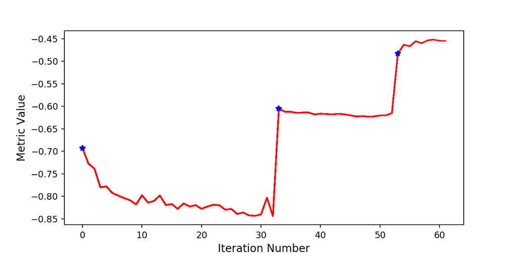

```
Final metric value: -0.45672759561042586
Optimizer's stopping condition: GradientDescentOptimizerv4Template: Convergence checker passed at iteration 9.
```

```python
# First re-define InitialTransform as before swapping Fixed with Moving:
# Initialize registration by aligning the centers of the two volumes.
# To qualitatively evaluate the result we use a linked cursor approach,
# click on one image and the corresponding point is added to the other image.

InitialTransform = sitk.CenteredTransformInitializer(FixedIm,
                                                     MovingIm,
                                                     sitk.Euler3DTransform(),
                                                     sitk.CenteredTransformInitializerFilter.GEOMETRY)

# Set the similarity metric and optimiser settings:
RegMethod = sitk.ImageRegistrationMethod()

# Similarity metric settings:
RegMethod.SetMetricAsMattesMutualInformation(numberOfHistogramBins=50)
RegMethod.SetMetricSamplingStrategy(RegMethod.RANDOM)
RegMethod.SetMetricSamplingPercentage(0.01)

# Set the interpolator:
RegMethod.SetInterpolator(sitk.sitkLinear)

# Optimiser settings:
RegMethod.SetOptimizerAsGradientDescent(learningRate=1.0,
                                        numberOfIterations=100,
                                        convergenceMinimumValue=1e-6,
                                        convergenceWindowSize=10)

RegMethod.SetOptimizerScalesFromPhysicalShift()

# Setup for the multi-resolution framework:
RegMethod.SetShrinkFactorsPerLevel(shrinkFactors = [4,2,1])
RegMethod.SetSmoothingSigmasPerLevel(smoothingSigmas=[2,1,0])
RegMethod.SmoothingSigmasAreSpecifiedInPhysicalUnitsOn()

# Don't optimize in-place, we would possibly like to run this cell multiple times:
RegMethod.SetInitialTransform(InitialTransform, inPlace=False)
""" Note: InitialTransform = sitk.CenteredTransformInitializerFilter.GEOMETRY """

# Connect all of the observers so that we can perform plotting during registration:
RegMethod.AddCommand(sitk.sitkStartEvent, rgui.start_plot)
RegMethod.AddCommand(sitk.sitkEndEvent, rgui.end_plot)
RegMethod.AddCommand(sitk.sitkMultiResolutionIterationEvent, rgui.update_multires_iterations)
RegMethod.AddCommand(sitk.sitkIterationEvent, lambda: rgui.plot_values(RegMethod))

FinalTransformClassical = RegMethod.Execute(FixedIm, MovingIm)

# Check the reason optimisation terminated:
print(f'Final metric value: {RegMethod.GetMetricValue()}')
print(f'Optimizer\'s stopping condition: {RegMethod.GetOptimizerStopConditionDescription()}')
```

```python
# Qualitatively evaluate the result using a linked cursor approach (visual evaluation):
gui.RegistrationPointDataAquisition(FixedIm, MovingIm, figure_size=(8,4),
                                    known_transformation=FinalTransformClassical);
```

### The points seem to correspond reasonably well, but the moving image doesn't look registered.

### 05/05 Correction: After re-evaluating cells the results now look as poor as the ones above.

```python
# Save the results to file:
#MovingResampled = sitk.Resample(MovingIm, FixedIm, FinalTransform,
#                                sitk.sitkLinear, 0.0, MovingIm.GetPixelID())

#sitk.WriteImage(MovingResampled, os.path.join(ExportDir, 'T2_3D_Slab_resampled.mha'))
#sitk.WriteTransform(FinalTransform, os.path.join(ExportDir, 'T2_3D_Slab_reg_to_HEAD_2-4_H40_SOFT_TISSUE.tfm'))
```

### Use ITK v4 registration framework:

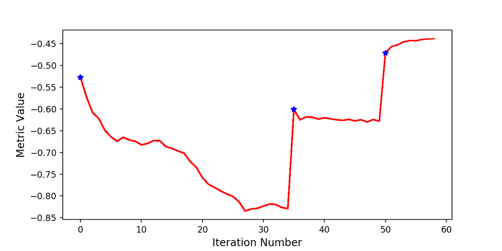

```
Final metric value: -0.4396963245746456
Optimizer's stopping condition: GradientDescentOptimizerv4Template: Convergence checker passed at iteration 9.
```

```python
# Define the registration method:
RegMethod = sitk.ImageRegistrationMethod()

# Similarity metric settings:
RegMethod.SetMetricAsMattesMutualInformation(numberOfHistogramBins=50)
RegMethod.SetMetricSamplingStrategy(RegMethod.RANDOM)
RegMethod.SetMetricSamplingPercentage(0.01)

# Set the interpolator:
RegMethod.SetInterpolator(sitk.sitkLinear)

# Optimizer settings:
RegMethod.SetOptimizerAsGradientDescent(learningRate=1.0,
                                        numberOfIterations=100,
                                        convergenceMinimumValue=1e-6,
                                        convergenceWindowSize=10)

RegMethod.SetOptimizerScalesFromPhysicalShift()

# Setup for the multi-resolution framework:
RegMethod.SetShrinkFactorsPerLevel(shrinkFactors = [4,2,1])
RegMethod.SetSmoothingSigmasPerLevel(smoothingSigmas=[2,1,0])
RegMethod.SmoothingSigmasAreSpecifiedInPhysicalUnitsOn()

""" Note the above is the same as the classical registration.  They depart from here: """

# Set the initial moving and optimised transforms:
OptimizedTransform = sitk.Euler3DTransform()
RegMethod.SetMovingInitialTransform(InitialTransform)
""" Note: InitialTransform = sitk.CenteredTransformInitializerFilter.GEOMETRY """
RegMethod.SetInitialTransform(OptimizedTransform, inPlace=False)

# Connect all of the observers so that we can perform plotting during registration:
RegMethod.AddCommand(sitk.sitkStartEvent, rgui.start_plot)
RegMethod.AddCommand(sitk.sitkEndEvent, rgui.end_plot)
RegMethod.AddCommand(sitk.sitkMultiResolutionIterationEvent, rgui.update_multires_iterations)
RegMethod.AddCommand(sitk.sitkIterationEvent, lambda: rgui.plot_values(RegMethod))

# Need to compose the transformations after registration.
FinalTransform_v4 = RegMethod.Execute(FixedIm, MovingIm)
#FinalTransform_v4.AddTransform(InitialTransform)

# Check the reason optimisation terminated:
print(f'Final metric value: {RegMethod.GetMetricValue()}')
print(f'Optimizer\'s stopping condition: {RegMethod.GetOptimizerStopConditionDescription()}')
```

```python
# Qualitatively evaluate the result using a linked cursor approach (visual evaluation):
gui.RegistrationPointDataAquisition(FixedIm, MovingIm, figure_size=(8,4),
                                    known_transformation=FinalTransform_v4);
```

### For some reason the gui doesn't seem to be showing the corresponding moving slice based on the cursor as it had for the classical registration...

### This time try using the identify transform as the initialiser:

```python
# Use the identity transform as the initial transform:
InitialTransform = sitk.Transform()

gui.RegistrationPointDataAquisition(FixedIm, MovingIm, figure_size=(8,4),
                                    known_transformation=InitialTransform);
```

```python
# Define the registration method:
RegMethod = sitk.ImageRegistrationMethod()

# Similarity metric settings:
RegMethod.SetMetricAsMattesMutualInformation(numberOfHistogramBins=50)
RegMethod.SetMetricSamplingStrategy(RegMethod.RANDOM)
RegMethod.SetMetricSamplingPercentage(0.01)

# Set the interpolator:
RegMethod.SetInterpolator(sitk.sitkLinear)

# Optimizer settings:
RegMethod.SetOptimizerAsGradientDescent(learningRate=1.0,
                                        numberOfIterations=100,
                                        convergenceMinimumValue=1e-6,
                                        convergenceWindowSize=10)

RegMethod.SetOptimizerScalesFromPhysicalShift()

# Setup for the multi-resolution framework:
RegMethod.SetShrinkFactorsPerLevel(shrinkFactors = [4,2,1])
RegMethod.SetSmoothingSigmasPerLevel(smoothingSigmas=[2,1,0])
RegMethod.SmoothingSigmasAreSpecifiedInPhysicalUnitsOn()

""" Note the above is the same as the classical registration.  They depart from here: """

# Set the initial moving and optimised transforms:
OptimizedTransform = sitk.Euler3DTransform()
RegMethod.SetMovingInitialTransform(InitialTransform)
""" Note: InitialTransform = sitk.Transform() i.e. identity transform """
RegMethod.SetInitialTransform(OptimizedTransform, inPlace=False)

# Connect all of the observers so that we can perform plotting during registration:
RegMethod.AddCommand(sitk.sitkStartEvent, rgui.start_plot)
RegMethod.AddCommand(sitk.sitkEndEvent, rgui.end_plot)
RegMethod.AddCommand(sitk.sitkMultiResolutionIterationEvent, rgui.update_multires_iterations)
RegMethod.AddCommand(sitk.sitkIterationEvent, lambda: rgui.plot_values(RegMethod))

# Need to compose the transformations after registration.
FinalTransform_v4 = RegMethod.Execute(FixedIm, MovingIm)
#FinalTransform_v4.AddTransform(InitialTransform)

# Check the reason optimisation terminated:
print(f'Final metric value: {RegMethod.GetMetricValue()}')
print(f'Optimizer\'s stopping condition: {RegMethod.GetOptimizerStopConditionDescription()}')
```

```
---------------------------------------------------------------------------
RuntimeError                              Traceback (most recent call last)
<ipython-input-53-88f42c3731ed> in <module>
     38
     39 # Need to compose the transformations after registration.
---> 40 FinalTransform_v4 = RegMethod.Execute(FixedIm, MovingIm)
     41 #FinalTransform_v4.AddTransform(InitialTransform)
     42

~\Anaconda37\lib\site-packages\simpleitk-1.2.0rc2.dev1162+g2a79d-py3.7-win-amd64.egg\SimpleITK\SimpleITK.py in Execute(self, fixed, moving)
  12131
  12132         """
> 12133         return _SimpleITK.ImageRegistrationMethod_Execute(self, fixed, moving)
  12134
  12135

RuntimeError: Exception thrown in SimpleITK ImageRegistrationMethod_Execute: C:\SimpleElastix\build_20200108\ITK-prefix\include\ITK-4.13\itkMattesMutualInformationImageToImageMetricv4.hxx:205:
itk::ERROR: MattesMutualInformationImageToImageMetricv4(000001A843334170): Joint PDF summed to zero
```

```python
# Get the patient positions:
img = sitk.ReadImage(FixedFilenames[0])
print('Fixed Patient position:  ' + img.GetMetaData('0018|5100'))
img = sitk.ReadImage(MovingFilenames[0])
print('Moving Patient position: ' + img.GetMetaData('0018|5100'))
```

```
Fixed Patient position:  HFS
Moving Patient position: HFS
```

### Try using CenteredTransformInitializer initialization:

Compare GEOMETRY and MOMENTS based approaches.

```python
# First GEOMETRY approach:
InitialTransform = sitk.CenteredTransformInitializer(FixedIm,
                                                     MovingIm,
                                                     sitk.Euler3DTransform(),
                                                     sitk.CenteredTransformInitializerFilter.GEOMETRY)

gui.RegistrationPointDataAquisition(FixedIm, MovingIm, figure_size=(8,4),
                                    known_transformation=InitialTransform);
```

```python
# Next MOMENTS approach:
InitialTransform = sitk.CenteredTransformInitializer(FixedIm,
                                                     MovingIm,
                                                     sitk.Euler3DTransform(),
                                                     sitk.CenteredTransformInitializerFilter.MOMENTS)

gui.RegistrationPointDataAquisition(FixedIm, MovingIm, figure_size=(8,4),
                                    known_transformation=InitialTransform);
```

### Both look highly inaccurate to me!

### Try using the Exhaustive optimizer initialization using CenteredTransformInitializer with GEOMETRY approach:

Compare GEOMETRY and MOMENTS approaches.

```python
InitialTransform = sitk.CenteredTransformInitializer(FixedIm,
                                                     MovingIm,
                                                     sitk.Euler3DTransform(),
                                                     sitk.CenteredTransformInitializerFilter.GEOMETRY)
RegMethod = sitk.ImageRegistrationMethod()
RegMethod.SetMetricAsMattesMutualInformation(numberOfHistogramBins=50)
RegMethod.SetMetricSamplingStrategy(RegMethod.RANDOM)
RegMethod.SetMetricSamplingPercentage(0.01)
RegMethod.SetInterpolator(sitk.sitkLinear)

# The order of parameters for the Euler3DTransform is [angle_x, angle_y, angle_z, t_x, t_y, t_z]. The parameter
# sampling grid is centered on the InitialTransform parameter values, that are all zero for the rotations. Given
# the number of steps, their length and optimizer scales we have:
# angle_x = 0
# angle_y = -pi, 0, pi
# angle_z = -pi, 0, pi
RegMethod.SetOptimizerAsExhaustive(numberOfSteps=[0,1,1,0,0,0], stepLength = np.pi)
RegMethod.SetOptimizerScales([1,1,1,1,1,1])

# Perform the registration in-place so that the InitialTransform is modified.
RegMethod.SetInitialTransform(InitialTransform, inPlace=True)
""" Note: InitialTransform = sitk.CenteredTransformInitializerFilter.GEOMETRY """
RegMethod.Execute(FixedIm, MovingIm)

gui.RegistrationPointDataAquisition(FixedIm, MovingIm, figure_size=(8,4));
```

### Try MOMENTS this time:

```python
InitialTransform = sitk.CenteredTransformInitializer(FixedIm,
                                                     MovingIm,
                                                     sitk.Euler3DTransform(),
                                                     sitk.CenteredTransformInitializerFilter.MOMENTS)
RegMethod = sitk.ImageRegistrationMethod()
RegMethod.SetMetricAsMattesMutualInformation(numberOfHistogramBins=50)
RegMethod.SetMetricSamplingStrategy(RegMethod.RANDOM)
RegMethod.SetMetricSamplingPercentage(0.01)
RegMethod.SetInterpolator(sitk.sitkLinear)

# The order of parameters for the Euler3DTransform is [angle_x, angle_y, angle_z, t_x, t_y, t_z]. The parameter
# sampling grid is centered on the InitialTransform parameter values, that are all zero for the rotations. Given
# the number of steps, their length and optimizer scales we have:
# angle_x = 0
# angle_y = -pi, 0, pi
# angle_z = -pi, 0, pi
RegMethod.SetOptimizerAsExhaustive(numberOfSteps=[0,1,1,0,0,0], stepLength = np.pi)
RegMethod.SetOptimizerScales([1,1,1,1,1,1])

# Perform the registration in-place so that the InitialTransform is modified.
RegMethod.SetInitialTransform(InitialTransform, inPlace=True)
""" Note: InitialTransform = sitk.CenteredTransformInitializerFilter.MOMENTS """
RegMethod.Execute(FixedIm, MovingIm)

gui.RegistrationPointDataAquisition(FixedIm, MovingIm, figure_size=(8,4));
```

### For some reason the interactive cursor feature is not working, so difficult to assess whether the results of the exhaustive optimiser are any better.

### This is the end of the example covering rigid transformations.

### 06/05/2020: Try another example:

### https://simpleitk.readthedocs.io/en/master/link_ImageRegistrationMethod1_docs.html

```python
import sys

sys.argv
```

```
['C:\\Users\\ctorti\\Anaconda37\\lib\\site-packages\\ipykernel_launcher.py',
 '-f',
 'C:\\Users\\ctorti\\AppData\\Roaming\\jupyter\\runtime\\kernel-2cfa1968-a538-4d35-a094-f1338e947ae6.json']
```

```python
def command_iteration(method) :
    print("{0:3} = {1:10.5f} : {2}".format(method.GetOptimizerIteration(),
                                   method.GetMetricValue(),
                                   method.GetOptimizerPosition()))

#if len ( sys.argv ) < 4:
#    print( "Usage: {0} <fixedImageFilter> <movingImageFile> <outputTransformFile>".format(sys.argv[0]))
#    sys.exit ( 1 )


#fixed = sitk.ReadImage(sys.argv[1], sitk.sitkFloat32)

#moving = sitk.ReadImage(sys.argv[2], sitk.sitkFloat32)

SwapFixedMoving = False
#SwapFixedMoving = True

if SwapFixedMoving:
    print('FixedDir and MovingDir swapped.')
else:
    print('FixedDir and MovingDir as originally defined.')

# Read in the 3D stack of Fixed DICOMs:
FixedReader = sitk.ImageSeriesReader()
#FixedReader = sitk.ImageSeriesReader(sitk.sitkFloat32)
if SwapFixedMoving:
    FixedNames = FixedReader.GetGDCMSeriesFileNames(MovingDir)
else:
    FixedNames = FixedReader.GetGDCMSeriesFileNames(FixedDir)
FixedReader.SetFileNames(FixedNames)
FixedIm = FixedReader.Execute()
FixedIm = sitk.Cast(FixedIm, sitk.sitkFloat32)

# Read in the 3D stack of Moving DICOMs:
MovingReader = sitk.ImageSeriesReader()
#MovingReader = sitk.ImageSeriesReader(sitk.sitkFloat32)
if SwapFixedMoving:
    MovingNames = MovingReader.GetGDCMSeriesFileNames(FixedDir)
else:
    MovingNames = MovingReader.GetGDCMSeriesFileNames(MovingDir)
MovingReader.SetFileNames(MovingNames)
MovingIm = MovingReader.Execute()
#MovingIm = MovingReader.Execute(sitk.sitkFloat32)
MovingIm = sitk.Cast(MovingIm, sitk.sitkFloat32)

# Registration:

R = sitk.ImageRegistrationMethod()
R.SetMetricAsMeanSquares()
R.SetOptimizerAsRegularStepGradientDescent(4.0, .01, 200 )
R.SetInitialTransform(sitk.TranslationTransform(FixedIm.GetDimension()))
R.SetInterpolator(sitk.sitkLinear)

R.AddCommand( sitk.sitkIterationEvent, lambda: command_iteration(R) )

outTx = R.Execute(FixedIm, MovingIm)

print("\n-------")
print(outTx)
print("Optimizer stop condition: {0}".format(R.GetOptimizerStopConditionDescription()))
print(" Iteration: {0}".format(R.GetOptimizerIteration()))
print(" Metric value: {0}".format(R.GetMetricValue()))

#sitk.WriteTransform(outTx,  sys.argv[3])

if ( not "SITK_NOSHOW" in os.environ ):

    resampler = sitk.ResampleImageFilter()
    resampler.SetReferenceImage(FixedIm);
    resampler.SetInterpolator(sitk.sitkLinear)
    resampler.SetDefaultPixelValue(100)
    resampler.SetTransform(outTx)

    MovingResampledIm = resampler.Execute(MovingIm)
    simg1 = sitk.Cast(sitk.RescaleIntensity(FixedIm), sitk.sitkUInt8)
    simg2 = sitk.Cast(sitk.RescaleIntensity(MovingResampledIm), sitk.sitkUInt8)
    cimg = sitk.Compose(simg1, simg2, simg1//2.+simg2//2.)
    if False:
        sitk.Show( cimg, "ImageRegistration1 Composition" )
        """ sitk::ERROR: No appropriate executable found.
        So rather than using procedural interface use the object oriented interface as
        shown here:
        https://simpleitk.readthedocs.io/en/master/link_ImageViewing_docs.html
        --> Now it works after having downloaded Fiji but the kernel gets stuck.
        """
    # Use the default image viewer:
    if False:
        ImViewer = sitk.ImageViewer()
        ImViewer.SetTitle('ImageRegistration1 Composition')
        ImViewer.Execute(cimg)
        """ Same as above.
        """
    # Change viewer, and display again.
    #ImViewer.SetApplication('/Applications/ITK-SNAP.app/Contents/MacOS/ITK-SNAP')
    #ImViewer.Execute(grid_image)

    # Change the viewer command, (use ITK-SNAP's -z option to open the image in zoomed mode)
    #ImViewer.SetCommand('/Applications/ITK-SNAP.app/Contents/MacOS/ITK-SNAP -z 2')
    #ImViewer.Execute(grid_image)


# Get info about FixedIm, MovingIm and MovingResampledIm:

#FixedDtype = str(FixedIm.dtype)
FixedDtype = FixedIm.GetPixelIDTypeAsString()
#MovingDtype = str(MovingIm.dtype)
MovingDtype = MovingIm.GetPixelIDTypeAsString()
MovingResampledDtype = MovingResampledIm.GetPixelIDTypeAsString()
print('\nFixedIm Dtype           =', FixedDtype)
print('MovingIm Dtype          =', MovingDtype)
print('MovingResampledIm Dtype =', MovingResampledDtype)

FixedSize = FixedIm.GetSize()
MovingSize = MovingIm.GetSize()
MovingResampledSize = MovingResampledIm.GetSize()
print('\nFixedIm Size           =', FixedSize)
print('MovingIm Size          =', MovingSize)
print('MovingResampledIm Size =', MovingResampledSize)

FixedSpacing = FixedIm.GetSpacing()
MovingSpacing = MovingIm.GetSpacing()
MovingResampledSpacing = MovingResampledIm.GetSpacing()
print('\nFixedIm Spacing           =', FixedSpacing)
print('MovingIm Spacing          =', MovingSpacing)
print('MovingResampledIm Spacing =', MovingResampledSpacing)

FixedOrigin = FixedIm.GetOrigin()
MovingOrigin = MovingIm.GetOrigin()
MovingResampledOrigin = MovingResampledIm.GetOrigin()
print('\nFixedIm Origin           =', FixedOrigin)
print('MovingIm Origin          =', MovingOrigin)
print('MovingResampledIm Origin =', MovingResampledOrigin)

FixedNda = sitk.GetArrayFromImage(FixedIm)
MovingNda = sitk.GetArrayFromImage(MovingIm)
MovingResampledNda = sitk.GetArrayFromImage(MovingResampledIm)
print(f'\nFixedIm Min, Max           = {np.min(FixedNda)}, {np.max(FixedNda)}')
print(f'MovingIm Min, Max          = {np.min(MovingNda)}, {np.max(MovingNda)}')
print(f'MovingResampledIm Min, Max = {np.min(MovingResampledNda)}, {np.max(MovingResampledNda)}')

if np.min(MovingResampledNda) == np.max(MovingResampledNda):
    print('\nMin/Max values of MovingResampledIm are the same!!!')
```

```
FixedDir and MovingDir as originally defined.

-------
itk::simple::Transform
 TranslationTransform (0000026447956180)
   RTTI typeinfo:   class itk::TranslationTransform<double,3>
   Reference Count: 2
   Modified Time: 41710
   Debug: Off
   Object Name:
   Observers:
     none
   Offset: [0, 0, 0]

Optimizer stop condition: RegularStepGradientDescentOptimizerv4: Gradient magnitude tolerance met after 0 iterations. Gradient magnitude (0) is less than gradient magnitude tolerance (0.0001).
 Iteration: 1
 Metric value: 1.7976931348623157e+308

FixedIm Dtype           = 32-bit float
MovingIm Dtype          = 32-bit float
MovingResampledIm Dtype = 32-bit float

FixedIm Size           = (256, 256, 160)
MovingIm Size          = (512, 512, 72)
MovingResampledIm Size = (256, 256, 160)

FixedIm Spacing           = (1.0, 1.0, 1.0)
MovingIm Spacing          = (0.423828125, 0.423828125, 2.4130020141601562)
MovingResampledIm Spacing = (1.0, 1.0, 1.0)

FixedIm Origin           = (-134.53753662109375, -167.07070922851562, -79.45004272460938)
MovingIm Origin          = (-108.2880859375, -282.97186279296875, 115.51118469238281)
MovingResampledIm Origin = (-134.53753662109375, -167.07070922851562, -79.45004272460938)

FixedIm Min, Max           = 0.0, 448.0
MovingIm Min, Max          = -1024.0, 3071.0
MovingResampledIm Min, Max = 100.0, 100.0

Min/Max values of MovingResampledIm are the same!!!
```

### After failing to execute the Image viewing example here:

### https://simpleitk.readthedocs.io/en/master/link_ImageViewing_docs.html

### I left a question here:

### https://github.com/SimpleITK/SimpleITK/issues/723

### Check results of resampling MovingIm:

```python
# First plot FixedIm and MovingIm using display_images:

interact(display_images,
         fixed_image_z=(0,FixedIm.GetSize()[2]-1),
         moving_image_z=(0,MovingIm.GetSize()[2]-1),
         fixed_npa = fixed(sitk.GetArrayFromImage(FixedIm)),
         moving_npa = fixed(sitk.GetArrayFromImage(MovingIm)),
         fixed_title = 'FixedIm',
         moving_title = 'MovingIm');
```

```python
# First plot FixedIm and MovingIm using display_images_v2:

interact(display_images_v2,
         fixed_image_z=(0,FixedIm.GetSize()[2]-1),
         moving_image_z=(0,MovingIm.GetSize()[2]-1),
         fixed_npa = fixed(sitk.GetArrayFromImage(FixedIm)),
         moving_npa = fixed(sitk.GetArrayFromImage(MovingIm)),
         fixed_title = 'FixedIm',
         moving_title = 'MovingIm');
```

```python
# Next plot FixedIm and MovingResampledIm using display_images:

interact(display_images,
         fixed_image_z=(0,FixedIm.GetSize()[2]-1),
         moving_image_z=(0,MovingResampledIm.GetSize()[2]-1),
         fixed_npa = fixed(sitk.GetArrayFromImage(FixedIm)),
         moving_npa = fixed(sitk.GetArrayFromImage(MovingResampledIm)),
         fixed_title = 'FixedIm',
         moving_title = 'MovingResampledIm');
```

```python
# Next plot FixedIm and MovingResampledIm using display_images_v2:

interact(display_images_v2,
         fixed_image_z=(0,FixedIm.GetSize()[2]-1),
         moving_image_z=(0,MovingResampledIm.GetSize()[2]-1),
         fixed_npa = fixed(sitk.GetArrayFromImage(FixedIm)),
         moving_npa = fixed(sitk.GetArrayFromImage(MovingResampledIm)),
         fixed_title = 'FixedIm',
         moving_title = 'MovingResampledIm');
```

### I've finally realised that the min/max values of MovingResampledIm are equal - and that's why the plots of MovingResampledIm are all black - not due to issues with normalisation in the colourmap!

```python
MovingResampledNda
```

```
array([[[100., 100., 100., ..., 100., 100., 100.],
        [100., 100., 100., ..., 100., 100., 100.],
        [100., 100., 100., ..., 100., 100., 100.],
        ...,
        [100., 100., 100., ..., 100., 100., 100.],
        [100., 100., 100., ..., 100., 100., 100.],
        [100., 100., 100., ..., 100., 100., 100.]],

       [[100., 100., 100., ..., 100., 100., 100.],
        [100., 100., 100., ..., 100., 100., 100.],
        [100., 100., 100., ..., 100., 100., 100.],
        ...,
        [100., 100., 100., ..., 100., 100., 100.],
        [100., 100., 100., ..., 100., 100., 100.],
        [100., 100., 100., ..., 100., 100., 100.]],

       [[100., 100., 100., ..., 100., 100., 100.],
        [100., 100., 100., ..., 100., 100., 100.],
        [100., 100., 100., ..., 100., 100., 100.],
        ...,
        [100., 100., 100., ..., 100., 100., 100.],
        [100., 100., 100., ..., 100., 100., 100.],
        [100., 100., 100., ..., 100., 100., 100.]],

       ...,

       [[100., 100., 100., ..., 100., 100., 100.],
        [100., 100., 100., ..., 100., 100., 100.],
        [100., 100., 100., ..., 100., 100., 100.],
        ...,
        [100., 100., 100., ..., 100., 100., 100.],
        [100., 100., 100., ..., 100., 100., 100.],
        [100., 100., 100., ..., 100., 100., 100.]],

       [[100., 100., 100., ..., 100., 100., 100.],
        [100., 100., 100., ..., 100., 100., 100.],
        [100., 100., 100., ..., 100., 100., 100.],
        ...,
        [100., 100., 100., ..., 100., 100., 100.],
        [100., 100., 100., ..., 100., 100., 100.],
        [100., 100., 100., ..., 100., 100., 100.]],

       [[100., 100., 100., ..., 100., 100., 100.],
        [100., 100., 100., ..., 100., 100., 100.],
        [100., 100., 100., ..., 100., 100., 100.],
        ...,
        [100., 100., 100., ..., 100., 100., 100.],
        [100., 100., 100., ..., 100., 100., 100.],
        [100., 100., 100., ..., 100., 100., 100.]]], dtype=float32)
```

### So now need to figure out why the values are the same.

### On page 13 here:

### https://simpleitk.org/SPIE2018_COURSE/images_and_resampling.pdf

### under "Common errors" there's talk of an empty (all black) image after resampling due to wrong settings for the resampling grid, or from using the inverse of the transformation.

### I'm not sure this applies to the above because I'm not getting zero values. But maybe it may still be the same root cause.

### I don't know what resampling grid was used above. Nothing stands out in the code as having anything to do with a resampling grid. The pdf linked above also doesn't explain where the sampling grid is within or how it's defined. Page 12 lists 3 methods of specifying the resampling grid that are all incomprehensible.

# 07.05/2020: Try using data that might be easier to work with. MR and CT/PET data have completely different physical locations and different resolutions and pixel spacings.

### Next try working with CT and PET (different resolutions and pixel spacings but same physical coordinates).

### If that still fails, then switch to two MR series (same resolution, same pixel spacing, same physical coordinates).

### Define the directories of Fixed and Moving and load the images:

```python
#FixedDir = r'C:\Temp\ACRIN_MR_DICOMs'
FixedDir = r'C:\Temp\ACRIN_PET_DICOMs'
MovingDir = r'C:\Temp\ACRIN_CT_DICOMs'

SwapFixedMoving = False
#SwapFixedMoving = True

if SwapFixedMoving:
    print('FixedDir and MovingDir swapped.')
else:
    print('FixedDir and MovingDir not swapped.')

# Read in the 3D stack of Fixed DICOMs:
FixedReader = sitk.ImageSeriesReader()
#FixedReader = sitk.ImageSeriesReader(sitk.sitkFloat32)
if SwapFixedMoving:
    FixedNames = FixedReader.GetGDCMSeriesFileNames(MovingDir)
else:
    FixedNames = FixedReader.GetGDCMSeriesFileNames(FixedDir)
FixedReader.SetFileNames(FixedNames)
FixedIm = FixedReader.Execute()
FixedIm = sitk.Cast(FixedIm, sitk.sitkFloat32)

# Read in the 3D stack of Moving DICOMs:
MovingReader = sitk.ImageSeriesReader()
#MovingReader = sitk.ImageSeriesReader(sitk.sitkFloat32)
if SwapFixedMoving:
    MovingNames = MovingReader.GetGDCMSeriesFileNames(FixedDir)
else:
    MovingNames = MovingReader.GetGDCMSeriesFileNames(MovingDir)
MovingReader.SetFileNames(MovingNames)
MovingIm = MovingReader.Execute()
#MovingIm = MovingReader.Execute(sitk.sitkFloat32)
MovingIm = sitk.Cast(MovingIm, sitk.sitkFloat32)

# Get some info on FixedIm and MovingIm:

#FixedDtype = str(FixedIm.dtype)
FixedDtype = FixedIm.GetPixelIDTypeAsString()
#MovingDtype = str(MovingIm.dtype)
MovingDtype = MovingIm.GetPixelIDTypeAsString()
print('\nFixedIm Dtype  =', FixedDtype)
print('MovingIm Dtype =', MovingDtype)

FixedSize = FixedIm.GetSize()
MovingSize = MovingIm.GetSize()
print('\nFixedIm Size  =', FixedSize)
print('MovingIm Size =', MovingSize)

FixedSpacing = FixedIm.GetSpacing()
MovingSpacing = MovingIm.GetSpacing()
print('\nFixedIm Spacing  =', FixedSpacing)
print('MovingIm Spacing =', MovingSpacing)

FixedOrigin = FixedIm.GetOrigin()
MovingOrigin = MovingIm.GetOrigin()
print('\nFixedIm Origin  =', FixedOrigin)
print('MovingIm Origin =', MovingOrigin)

FixedNda = sitk.GetArrayFromImage(FixedIm)
MovingNda = sitk.GetArrayFromImage(MovingIm)
print(f'\nFixedIm Min, Max  = {np.min(FixedNda)}, {np.max(FixedNda)}')
print(f'MovingIm Min, Max = {np.min(MovingNda)}, {np.max(MovingNda)}')
```

```
FixedDir and MovingDir not swapped.

FixedIm Dtype  = 32-bit float
MovingIm Dtype = 32-bit float

FixedIm Size  = (256, 256, 47)
MovingIm Size = (512, 512, 72)

FixedIm Spacing  = (1.171875, 1.171875, 3.2699966430664062)
MovingIm Spacing = (0.423828125, 0.423828125, 2.4130020141601562)

FixedIm Origin  = (-149.4140625, -149.4140625, -130.89999389648438)
MovingIm Origin = (-108.2880859375, -282.97186279296875, 115.51118469238281)

FixedIm Min, Max  = 0.0, 7581.92333984375
MovingIm Min, Max = -1024.0, 3071.0
```

### Looks like the PET/CT data do not have the same physical coordinates.

# Work with MR only data sets.

### Define the directories of Fixed and Moving and load the images:

```python
RootDir = r'C:\Data\Cancer imaging archive\ACRIN-FMISO-Brain\ACRIN-FMISO-Brain-011'
FixedDir = os.path.join(RootDir, r'04-10-1960-MRI Brain wwo Contrast-69626\8-T1 SE AXIAL POST FS FC-59362')
MovingDir = os.path.join(RootDir, r'06-11-1961-MRI Brain wwo Contrast-79433\8-T1 SE AXIAL POST FS FC-81428')

SwapFixedMoving = False
#SwapFixedMoving = True

if SwapFixedMoving:
    print('FixedDir and MovingDir swapped.')
else:
    print('FixedDir and MovingDir not swapped.')

# Read in the 3D stack of Fixed DICOMs:
FixedReader = sitk.ImageSeriesReader()
#FixedReader = sitk.ImageSeriesReader(sitk.sitkFloat32)
if SwapFixedMoving:
    FixedNames = FixedReader.GetGDCMSeriesFileNames(MovingDir)
else:
    FixedNames = FixedReader.GetGDCMSeriesFileNames(FixedDir)
FixedReader.SetFileNames(FixedNames)
FixedIm = FixedReader.Execute()
FixedIm = sitk.Cast(FixedIm, sitk.sitkFloat32)

# Read in the 3D stack of Moving DICOMs:
MovingReader = sitk.ImageSeriesReader()
#MovingReader = sitk.ImageSeriesReader(sitk.sitkFloat32)
if SwapFixedMoving:
    MovingNames = MovingReader.GetGDCMSeriesFileNames(FixedDir)
else:
    MovingNames = MovingReader.GetGDCMSeriesFileNames(MovingDir)
MovingReader.SetFileNames(MovingNames)
MovingIm = MovingReader.Execute()
#MovingIm = MovingReader.Execute(sitk.sitkFloat32)
MovingIm = sitk.Cast(MovingIm, sitk.sitkFloat32)

# Get some info on FixedIm and MovingIm:

#FixedDtype = str(FixedIm.dtype)
FixedDtype = FixedIm.GetPixelIDTypeAsString()
#MovingDtype = str(MovingIm.dtype)
MovingDtype = MovingIm.GetPixelIDTypeAsString()
print('\nFixedIm Dtype  =', FixedDtype)
print('MovingIm Dtype =', MovingDtype)

FixedSize = FixedIm.GetSize()
MovingSize = MovingIm.GetSize()
print('\nFixedIm Size  =', FixedSize)
print('MovingIm Size =', MovingSize)

FixedSpacing = FixedIm.GetSpacing()
MovingSpacing = MovingIm.GetSpacing()
print('\nFixedIm Spacing  =', FixedSpacing)
print('MovingIm Spacing =', MovingSpacing)

FixedOrigin = FixedIm.GetOrigin()
MovingOrigin = MovingIm.GetOrigin()
print('\nFixedIm Origin  =', FixedOrigin)
print('MovingIm Origin =', MovingOrigin)

FixedNda = sitk.GetArrayFromImage(FixedIm)
MovingNda = sitk.GetArrayFromImage(MovingIm)
print(f'\nFixedIm Min, Max  = {np.min(FixedNda)}, {np.max(FixedNda)}')
print(f'MovingIm Min, Max = {np.min(MovingNda)}, {np.max(MovingNda)}')
```

```
FixedDir and MovingDir not swapped.

FixedIm Dtype  = 32-bit float
MovingIm Dtype = 32-bit float

FixedIm Size  = (212, 256, 30)
MovingIm Size = (192, 256, 35)

FixedIm Spacing  = (0.8984375, 0.8984375, 5.0)
MovingIm Spacing = (0.9375, 0.9375, 5.0)

FixedIm Origin  = (-104.92378234863281, -152.4906463623047, -9.22148609161377)
MovingIm Origin = (-115.14457702636719, -124.83148193359375, -10.8151273727417)

FixedIm Min, Max  = 0.0, 2015.0
MovingIm Min, Max = 0.0, 1870.0
```

```python
gui.MultiImageDisplay(image_list = [FixedIm, MovingIm],
                      title_list = ['Fixed', 'Moving'], figure_size=(8,4));
```

```python
interact(display_images_v2,
         fixed_image_z=(0,FixedIm.GetSize()[2]-1),
         moving_image_z=(0,MovingIm.GetSize()[2]-1),
         fixed_npa = fixed(sitk.GetArrayFromImage(FixedIm)),
         moving_npa = fixed(sitk.GetArrayFromImage(MovingIm)),
         fixed_title = 'Fixed image',
         moving_title = 'Moving image');
```

### Trying using SimpleElastix framework again:

```python
# Start timing:
times = []
times.append(time.time())

# Register the 3D images:
ImFilter = sitk.ElastixImageFilter()
ImFilter.SetFixedImage(FixedIm)
ImFilter.SetMovingImage(MovingIm)
#ImFilter.SetMovingImage(FixedIm)
#ImFilter.SetParameterMap(sitk.GetDefaultParameterMap('groupwise'))
ImFilter.SetParameterMap(sitk.GetDefaultParameterMap('affine'))
ImFilter.LogToConsoleOn()
ImFilter.LogToFileOn()
RegIm = ImFilter.Execute()

times.append(time.time())
Dtime = round(times[-1] - times[-2], 1)
print(f'\nTook {Dtime} s to register the 3D image stacks.')
```

```
Took 7.8 s to register the 3D image stacks.
```

```python
# Get some info on FixedIm, MovingIm and RegIm:

FixedDtype = FixedIm.GetPixelIDTypeAsString()
MovingDtype = MovingIm.GetPixelIDTypeAsString()
RegDtype = RegIm.GetPixelIDTypeAsString()
print('\nFixedIm Dtype  =', FixedDtype)
print('MovingIm Dtype =', MovingDtype)
print('RegIm Dtype    =', RegDtype)

FixedSize = FixedIm.GetSize()
MovingSize = MovingIm.GetSize()
RegSize = RegIm.GetSize()
print('\nFixedIm Size  =', FixedSize)
print('MovingIm Size =', MovingSize)
print('RegIm Size    =', RegSize)

FixedSpacing = FixedIm.GetSpacing()
MovingSpacing = MovingIm.GetSpacing()
RegSpacing = RegIm.GetSpacing()
print('\nFixedIm Spacing  =', FixedSpacing)
print('MovingIm Spacing =', MovingSpacing)
print('RegIm Spacing bb =', RegSpacing)

FixedOrigin = FixedIm.GetOrigin()
MovingOrigin = MovingIm.GetOrigin()
RegOrigin = RegIm.GetOrigin()
print('\nFixedIm Origin  =', FixedOrigin)
print('MovingIm Origin =', MovingOrigin)
print('RegIm Origin    =', RegOrigin)

FixedNda = sitk.GetArrayFromImage(FixedIm)
MovingNda = sitk.GetArrayFromImage(MovingIm)
RegNda = sitk.GetArrayFromImage(RegIm)
print(f'\nFixedIm Min, Max  = {np.min(FixedNda)}, {np.max(FixedNda)}')
print(f'MovingIm Min, Max = {np.min(MovingNda)}, {np.max(MovingNda)}')
print(f'RegIm Min, Max    = {np.min(RegNda)}, {np.max(RegNda)}')

# Get the Transform Parameter Map:
#TransformParameterMap = sitk.GetTransformParameterMap() # AttributeError: module 'SimpleITK'
# has no attribute 'GetTransformParameterMap'
TransformParameterMap = ImFilter.GetTransformParameterMap()
TransformParameterMap
```

```
FixedIm Dtype  = 32-bit float
MovingIm Dtype = 32-bit float
RegIm Dtype    = 32-bit float

FixedIm Size  = (212, 256, 30)
MovingIm Size = (192, 256, 35)
RegIm Size    = (212, 256, 30)

FixedIm Spacing  = (0.8984375, 0.8984375, 5.0)
MovingIm Spacing = (0.9375, 0.9375, 5.0)
RegIm Spacing bb = (0.8984375, 0.8984375, 5.0)

FixedIm Origin  = (-104.92378234863281, -152.4906463623047, -9.22148609161377)
MovingIm Origin = (-115.14457702636719, -124.83148193359375, -10.8151273727417)
RegIm Origin    = (-104.92378234863281, -152.4906463623047, -9.22148609161377)

FixedIm Min, Max  = 0.0, 2015.0
MovingIm Min, Max = 0.0, 1870.0
RegIm Min, Max    = -136.6031036376953, 1769.6104736328125
```

```
(<SimpleITK.SimpleITK.ParameterMap; proxy of <Swig Object of type 'std::map< std::string,std::vector< std::string,std::allocator< std::string > >,std::less< std::string >,std::allocator< std::pair< std::string const,std::vector< std::string,std::allocator< std::string > > > > > *' at 0x000002C38A3A8…
```

```python
# Try to get the transformation (transformix) as here:
# https://simpleelastix.readthedocs.io/PointBasedRegistration.html

TransformixImFilter = sitk.TransformixImageFilter()
TransformixImFilter
```

```
<SimpleITK.SimpleITK.TransformixImageFilter; proxy of <Swig Object of type 'itk::simple::TransformixImageFilter::Self *' at 0x000002C38A4AC300> >
```

```python
gui.MultiImageDisplay(image_list = [MovingIm, RegIm],
                      title_list = ['Moving', 'Registered'], figure_size=(8,4));
```

```python
# Qualitatively evaluate the result using a linked cursor approach (visual evaluation):
gui.RegistrationPointDataAquisition(FixedIm, MovingIm, figure_size=(8,4),
                                    known_transformation=ImFilter);
```

```python
# Qualitatively evaluate the result using a linked cursor approach (visual evaluation):
gui.RegistrationPointDataAquisition(FixedIm, MovingIm, figure_size=(8,4),
                                    known_transformation=TransformixImFilter);
```

```python
interact(display_images_v3,
         fixed_image_z=(0,FixedIm.GetSize()[2]-1),
         moving_image_z=(0,MovingIm.GetSize()[2]-1),
         registered_image_z=(0,RegIm.GetSize()[2]-1),
         fixed_npa = fixed(sitk.GetArrayFromImage(FixedIm)),
         moving_npa = fixed(sitk.GetArrayFromImage(MovingIm)),
         registered_npa = fixed(sitk.GetArrayFromImage(RegIm)),
         fixed_title = 'Fixed image',
         moving_title = 'Moving image',
         registered_title = 'Registered image');
```

# 11/05/2020: Repeat above but this time using data downloaded from XNAT with view to start working with ROI Collection:

### Download XNAT data (DICOMs, ROI Collection):

```python
import importlib

import GetXnatData
importlib.reload(GetXnatData)
from GetXnatData import GetXnatData

import CopyRoi
importlib.reload(CopyRoi)
from CopyRoi import CopyRoi


"""
Make selections below by un-commenting the desired option.
"""

# Define the XNAT address, username and password:
XnatAddress = 'http://10.1.1.17'
XnatUsername = 'admin'
XnatPassword = 'admin'

# Decide on the subject:
Subject = 'ACRIN-FMISO-Brain-011'
#Subject = ''

# Decide whether to copy to select PET or CT scans:
#CopyFrom = 'MR'
#CopyTo = 'PET'
#CopyTo = 'CT'
CopyFrom = 'MR_4'# 1960-04-10 69626
CopyTo = 'MR_12' # 1961-06-11 79433

# Decide on what feature to use to manually determine the required shift
# along the scan direction:
#ShiftFeature = 'peak of nose'
#ShiftFeature = 'infinity-like structure in brain'
#ShiftFeature = 'lens of eye'
#ShiftFeature = 'butterfly-like structure in brain'
ShiftFeature = '' # i.e. no shifting to be done

# Decide whether or not to print some intermediate results for debugging purposes:
""" Some of the more important/useful intermediate results are printed by default. """
#Debug = True
Debug = False



# Define the REST variables that correspond to the Source ROI Collection,
# the corresponding Source DICOMs, and the Target DICOMs that the ROI
# Collection is to be copied to:
if Subject == 'ACRIN-FMISO-Brain-011' and CopyFrom == 'MR':
    SourceRoiProjLabel = 'ACRIN'
    SourceRoiSubjLabel = 'ACRIN-FMISO-Brain-011'
    SourceRoiExpLabel = 'ACRIN-FMISO-Brain-011_MR_2'
    SourceRoiLabelDateTime = '20200330'
    SourceSeriesNo = '5'
    SourceSeriesDesc = 'T2 3D Slab'

if Subject == 'ACRIN-FMISO-Brain-011' and CopyTo == 'PET':
    TargetDicomProjLabel = 'ACRIN'
    TargetDicomSubjLabel = 'ACRIN-FMISO-Brain-011'
    TargetDicomExpLabel = 'ACRIN-FMISO-Brain-011_CT_PET_1'
    TargetSeriesNo = '3'
    TargetSeriesDesc = '3D_Brain miso '

if Subject == 'ACRIN-FMISO-Brain-011' and CopyTo == 'CT':
    TargetDicomProjLabel = 'ACRIN'
    TargetDicomSubjLabel = 'ACRIN-FMISO-Brain-011'
    TargetDicomExpLabel = 'ACRIN-FMISO-Brain-011_CT_19610312'
    TargetSeriesNo = '2'
    TargetSeriesDesc = 'HEAD 2.4 H40 SOFT TISSUE'

if Subject == 'ACRIN-FMISO-Brain-011' and CopyFrom == 'MR_4' and CopyTo == 'MR_12':
    SourceRoiProjLabel = 'ACRIN'
    SourceRoiSubjLabel = 'ACRIN-FMISO-Brain-011'
    SourceRoiExpLabel = 'ACRIN-FMISO-Brain-011_MR_4'
    SourceRoiLabelDateTime = '20200511'
    SourceSeriesNo = '8'
    SourceSeriesDesc = 'T1 SE AXIAL POST FS FC'

    TargetDicomProjLabel = 'ACRIN'
    TargetDicomSubjLabel = 'ACRIN-FMISO-Brain-011'
    TargetDicomExpLabel = 'ACRIN-FMISO-Brain-011_MR_12'
    TargetSeriesNo = '8'
    TargetSeriesDesc = 'T1 SE AXIAL POST FS FC'


# Define the root directory where DICOMs will be downloaded from XNAT to:
""" Note: Files will be downloaded to RootDir\TodaysDate SourceRoiProjLabel"""
RootDir = r'C:\Temp'

# Get the data from XNAT:
DataDict = GetXnatData(XnatAddress=XnatAddress,
                       XnatUsername=XnatUsername,
                       XnatPassword=XnatPassword,
                       RootDir=RootDir,
                       CopyFrom=CopyFrom,
                       CopyTo=CopyTo,
                       SourceRoiProjLabel=SourceRoiProjLabel,
                       SourceRoiSubjLabel=SourceRoiSubjLabel,
                       SourceRoiExpLabel=SourceRoiExpLabel,
                       SourceRoiLabelDateTime=SourceRoiLabelDateTime,
                       SourceSeriesNo=SourceSeriesNo,
                       SourceSeriesDesc=SourceSeriesDesc,
                       TargetDicomProjLabel=TargetDicomProjLabel,
                       TargetDicomSubjLabel=TargetDicomSubjLabel,
                       TargetDicomExpLabel=TargetDicomExpLabel,
                       TargetSeriesNo=TargetSeriesNo,
                       TargetSeriesDesc=TargetSeriesDesc,
                       Debug=Debug)



""" 11/05/2020:
This might need modifying for 3D registrations: """
if False:
    # Run CopyRoi():

    # Define the scan direction:
    ScanDirection = 'z'

    # Select the amount to shift the ScanDirection positions of the Target DICOMs by:
    """
    e.g. If ScanDirection = 'z', and Shift = 3, the z component of the Image Position
    Patient for the Target DICOMs will be shifted by 3 mm, and the resulting DICOMs
    stored in a new list called ShiftedDicoms. If Shift = 0, no shift will be applied.
    """
    # For Sarcoma dataset, use the difference between the Distance Source to Detector
    # (949.075) and Table Height (170) of the CT scan as the z-position correction:
    #Shift = 949.075 - 170

    # For ACRIN dataset, the Distance Source to Detector and Table Height tags are
    # empty, so need to use anatomical features instead:
    if ShiftFeature and Subject == 'ACRIN-FMISO-Brain-011':
        if CopyFrom == 'MR' and CopyTo == 'PET':
            if 'nose' in ShiftFeature:
                # Using the z positions where visually the "peak" of the patient's nose could
                # be seen maximally:
                ##Shift = -117.82 - (- 52.45) # = z_PET - z_MR (slice 43/47 and 133/160) <-- this one is incorrect
                Shift = -52.45 - (- 117.82) # = z_MR - z_PET (slice 133/160 and 43/47) <-- this is correct

            if 'infinity' in ShiftFeature:
                # or using the infinity-like structure in the brain:
                #Shift = -101.47 - (- 36.45) # = z_PET - z_MR (slice 38/47 and 117/160) <-- this one is incorrect
                Shift = -36.45 - (- 101.47) # = z_MR - z_PET (slice 117/160 and 48/47) <-- this is correct

        if CopyFrom == 'MR' and CopyTo == 'CT':
            if 'lens' in ShiftFeature:
                # Using the slices that maximise the size of the eye's lens:
                Shift = -21.450044136494 - 136.74918721324 # z_MR - z_CT (slice 102/160 and 10/72) = -158.199231349734

            if 'butterfly' in ShiftFeature:
                # Using the slices that show the butterfly-like structure with some dark fine structures within them:
                Shift = 14.549955863506 - 204.33718721324 # z_MR - z_CT (slice 66/160 and 39/72) = -189.787231349734

    # Don't apply any shift:
    if not ShiftFeature:
        Shift = 0

    # Select the registration method(s) to run:
    """
    Note: One or more registrations will be applied in a for loop depending on the
    number of strings in RegMethods.  RegMethods must be an array of one or more
    strings.  If it contains an empty string, i.e. '', no registration will be applied.
    """
    #RegMethods = ['rigid', 'affine', 'non-rigid']
    #RegMethods = ['rigid']
    RegMethods = ['affine']
    #RegMethods = ['non-rigid']

    # Don't apply any registration:
    #RegMethods = ['']

    # Decide whether or not to delete the Source and Target DICOMs downloaded from
    # XNAT when done:
    #DelDicoms = True
    DelDicoms = False

    # Decide whether or not to re-run registrations if the registered DICOMs already
    # exist (i.e. have already been exported locally):
    """ Since registrations are time consuming this can be helpful. """
    #RerunReg = True
    RerunReg = False

    # Decide whether or not to print some intermediate results for debugging purposes:
    """ Some of the more important/useful intermediate results are printed by default. """
    #Debug = True
    Debug = False

    # Run CopyRoi(), looping through each RegMethod in RegMethods:
    for RegMethod in RegMethods:
        if Shift and RegMethod:
            print('\n\n\nCopying ROI Collection from', SourceSeriesDesc, 'to', \
                  TargetSeriesDesc, ',\n applying shift to', ScanDirection + '-direction and', \
                  RegMethod, 'registration...\n\n\n')
        elif Shift and not RegMethod:
            print('\n\n\nCopying ROI Collection from', SourceSeriesDesc, 'to', \
                  TargetSeriesDesc, ',\n applying shift to', ScanDirection + '-direction ...\n\n\n')
        elif not Shift and RegMethod:
            print('\n\n\nCopying ROI Collection from', SourceSeriesDesc, 'to', \
                  TargetSeriesDesc, ',\n applying', RegMethod, 'registration...\n\n\n')
        elif not Shift and not RegMethod:
            print('\n\n\nCopying ROI Collection from', SourceSeriesDesc, 'to', \
                  TargetSeriesDesc, '...\n\n\n')

        SourceDicoms, SourceRois,\
        TargetDicoms, TargetRois,\
        ShiftedDicoms, ShiftedRois,\
        RemappedSourceDicoms, RemappedSourceRois,\
        RemappedTargetDicoms, RemappedTargetRois,\
        FixedDicoms, FixedRois,\
        MovingDicoms, MovingRois,\
        RegisteredDicoms, RegisteredRois,\
        DataDict = CopyRoi(DataDict=DataDict,
                           SearchBy=ScanDirection,
                           Shift=Shift,
                           ShiftFeature=ShiftFeature,
                           RegMethod=RegMethod,
                           DelDicoms=DelDicoms,
                           RerunReg=RerunReg)

        """ Note:  RemappedTargetDicoms will actually be RemappedShiftedTargetDicoms if Shift != 0. """
```

```
100% of  33.1 KiB |################################|  10.8 MiB/s Time:  0:00:00
```

```
Downloading the DICOM-RTSTRUCT file to be copied: AIM_20200511_073405.dcm

Downloading the DICOM files that the DICOM-RTSTRUCT file relate to..
```

[output not shown]

```
Downloading the DICOM files that the DICOM-RTSTRUCT file is to be overlaid on..
```

[output not shown]

```
Took 8.3 s to download data from XNAT.
```

```python
DataDict
```

```
{'XnatAddress': 'http://10.1.1.17',
 'XnatUsername': 'admin',
 'XnatPassword': 'admin',
 'RootDir': 'C:\\Temp\\2020-05-11 ACRIN MR_4 to MR_12',
 'Debug': False,
 'Source': {'RoiProjLabel': 'ACRIN',
  'RoiSubjLabel': 'ACRIN-FMISO-Brain-011',
  'RoiExpLabel': 'ACRIN-FMISO-Brain-011_MR_4',
  'RoiLabelDateTime': '20200511',
  'SeriesNo': '8',
  'SeriesDesc': 'T1 SE AXIAL POST FS FC',
  'RoiDir': 'C:\\Temp\\2020-05-11 ACRIN MR_4 to MR_12\\8 T1 SE AXIAL POST FS FC ROIs (source)',
  'DicomDir': 'C:\\Temp\\2020-05-11 ACRIN MR_4 to MR_12\\8 T1 SE AXIAL POST FS FC DICOMs (source)',
  'SliceNos': [],
  'RoiFpath': 'C:\\Temp\\2020-05-11 ACRIN MR_4 to MR_12\\8 T1 SE AXIAL POST FS FC ROIs (source)\\AIM_20200511_073405.dcm'},
 'Target': {'DicomProjLabel': 'ACRIN',
  'DicomSubjLabel': 'ACRIN-FMISO-Brain-011',
  'DicomExpLabel': 'ACRIN-FMISO-Brain-011_MR_12',
  'SeriesNo': '8',
  'SeriesDesc': 'T1 SE AXIAL POST FS FC',
  'RoiDir': 'C:\\Temp\\2020-05-11 ACRIN MR_4 to MR_12\\8 T1 SE AXIAL POST FS FC ROIs (target)',
  'DicomDir': 'C:\\Temp\\2020-05-11 ACRIN MR_4 to MR_12\\8 T1 SE AXIAL POST FS FC DICOMs (target)',
  'SliceNos': []}}
```

### Export DataDict:

```python
import json

# Create filepath for json file:
JsonFpath = os.path.join(DataDict['RootDir'], 'DataDict.json')

# Export DataDict:
data = json.dumps(DataDict)
file = open(JsonFpath, 'w')
file.write(data)
file.close()
```

### Import DataDict:

```python
import json

ImportDir = r'C:\Temp\2020-05-13 ACRIN MR_4 to MR_12'
JsonFpath = os.path.join(ImportDir, 'DataDict.json')

file = open(JsonFpath)
DataDict = json.load(file)
file.close()

DataDict
```

```
{'XnatAddress': 'http://10.1.1.17',
 'XnatUsername': 'admin',
 'XnatPassword': 'admin',
 'RootDir': 'C:\\Temp\\2020-05-13 ACRIN MR_4 to MR_12',
 'Debug': False,
 'Source': {'RoiProjLabel': 'ACRIN',
  'RoiSubjLabel': 'ACRIN-FMISO-Brain-011',
  'RoiExpLabel': 'ACRIN-FMISO-Brain-011_MR_4',
  'RoiLabelDateTime': '20200511',
  'SeriesNo': '8',
  'SeriesDesc': 'T1 SE AXIAL POST FS FC',
  'RoiDir': 'C:\\Temp\\2020-05-13 ACRIN MR_4 to MR_12\\8 T1 SE AXIAL POST FS FC ROIs (source)',
  'DicomDir': 'C:\\Temp\\2020-05-13 ACRIN MR_4 to MR_12\\8 T1 SE AXIAL POST FS FC DICOMs (source)',
  'SliceNos': [],
  'RoiFpath': 'C:\\Temp\\2020-05-13 ACRIN MR_4 to MR_12\\8 T1 SE AXIAL POST FS FC ROIs (source)\\AIM_20200511_073405.dcm'},
 'Target': {'DicomProjLabel': 'ACRIN',
  'DicomSubjLabel': 'ACRIN-FMISO-Brain-011',
  'DicomExpLabel': 'ACRIN-FMISO-Brain-011_MR_12',
  'SeriesNo': '8',
  'SeriesDesc': 'T1 SE AXIAL POST FS FC',
  'RoiDir': 'C:\\Temp\\2020-05-13 ACRIN MR_4 to MR_12\\8 T1 SE AXIAL POST FS FC ROIs (target)',
  'DicomDir': 'C:\\Temp\\2020-05-13 ACRIN MR_4 to MR_12\\8 T1 SE AXIAL POST FS FC DICOMs (target)',
  'SliceNos': []}}
```

```python
interact(display_images_v3,
         fixed_image_z=(0,FixedIm.GetSize()[2]-1),
         moving_image_z=(0,MovingIm.GetSize()[2]-1),
         registered_image_z=(0,RegIm.GetSize()[2]-1),
         fixed_npa = fixed(sitk.GetArrayFromImage(FixedIm)),
         moving_npa = fixed(sitk.GetArrayFromImage(MovingIm)),
         registered_npa = fixed(sitk.GetArrayFromImage(RegIm)),
         fixed_title = 'Fixed image',
         moving_title = 'Moving image',
         registered_title = 'Registered image');
```

### Define FixedDir and MovingDir based on the directories contained in DataDict:

```python
FixedDir = DataDict['Source']['DicomDir']
MovingDir = DataDict['Target']['DicomDir']

SwapFixedMoving = False
#SwapFixedMoving = True

if SwapFixedMoving:
    print('FixedDir and MovingDir swapped.')
else:
    print('FixedDir and MovingDir not swapped.')

# Read in the 3D stack of Fixed DICOMs:
FixedReader = sitk.ImageSeriesReader()
#FixedReader = sitk.ImageSeriesReader(sitk.sitkFloat32)
if SwapFixedMoving:
    FixedNames = FixedReader.GetGDCMSeriesFileNames(MovingDir)
else:
    FixedNames = FixedReader.GetGDCMSeriesFileNames(FixedDir)
FixedReader.SetFileNames(FixedNames)
FixedIm = FixedReader.Execute()
FixedIm = sitk.Cast(FixedIm, sitk.sitkFloat32)

# Read in the 3D stack of Moving DICOMs:
MovingReader = sitk.ImageSeriesReader()
#MovingReader = sitk.ImageSeriesReader(sitk.sitkFloat32)
if SwapFixedMoving:
    MovingNames = MovingReader.GetGDCMSeriesFileNames(FixedDir)
else:
    MovingNames = MovingReader.GetGDCMSeriesFileNames(MovingDir)
MovingReader.SetFileNames(MovingNames)
MovingIm = MovingReader.Execute()
#MovingIm = MovingReader.Execute(sitk.sitkFloat32)
MovingIm = sitk.Cast(MovingIm, sitk.sitkFloat32)

# Get some info on FixedIm and MovingIm:

#FixedDtype = str(FixedIm.dtype)
FixedDtype = FixedIm.GetPixelIDTypeAsString()
#MovingDtype = str(MovingIm.dtype)
MovingDtype = MovingIm.GetPixelIDTypeAsString()
print('\nFixedIm Dtype  =', FixedDtype)
print('MovingIm Dtype =', MovingDtype)

FixedSize = FixedIm.GetSize()
MovingSize = MovingIm.GetSize()
print('\nFixedIm Size  =', FixedSize)
print('MovingIm Size =', MovingSize)

FixedSpacing = FixedIm.GetSpacing()
MovingSpacing = MovingIm.GetSpacing()
print('\nFixedIm Spacing  =', FixedSpacing)
print('MovingIm Spacing =', MovingSpacing)

FixedOrigin = FixedIm.GetOrigin()
MovingOrigin = MovingIm.GetOrigin()
print('\nFixedIm Origin  =', FixedOrigin)
print('MovingIm Origin =', MovingOrigin)

FixedNda = sitk.GetArrayFromImage(FixedIm)
MovingNda = sitk.GetArrayFromImage(MovingIm)
print(f'\nFixedIm Min, Max  = {np.min(FixedNda)}, {np.max(FixedNda)}')
print(f'MovingIm Min, Max = {np.min(MovingNda)}, {np.max(MovingNda)}')
```

```
FixedDir and MovingDir not swapped.

FixedIm Dtype  = 32-bit float
MovingIm Dtype = 32-bit float

FixedIm Size  = (212, 256, 30)
MovingIm Size = (192, 256, 35)

FixedIm Spacing  = (0.8984375, 0.8984375, 5.0)
MovingIm Spacing = (0.9375, 0.9375, 5.0)

FixedIm Origin  = (-104.92378234863281, -152.4906463623047, -9.22148609161377)
MovingIm Origin = (-115.14457702636719, -124.83148193359375, -10.8151273727417)

FixedIm Min, Max  = 0.0, 2015.0
MovingIm Min, Max = 0.0, 1870.0
```

### Use SimpleElastix to register MovingIm to FixedIm:

```python
# Start timing:
times = []
times.append(time.time())

# Register the 3D images:
ElastixImFilt = sitk.ElastixImageFilter()
ElastixImFilt.SetFixedImage(FixedIm)
ElastixImFilt.SetMovingImage(MovingIm)
#ElastixImFilt.SetMovingImage(FixedIm)
#ElastixImFilt.SetParameterMap(sitk.GetDefaultParameterMap('groupwise'))
ElastixImFilt.SetParameterMap(sitk.GetDefaultParameterMap('affine'))
ElastixImFilt.LogToConsoleOn()
ElastixImFilt.LogToFileOn()
RegIm = ElastixImFilt.Execute()

times.append(time.time())
Dtime = round(times[-1] - times[-2], 1)
print(f'\nTook {Dtime} s to register the 3D image stacks.')
```

```
Took 16.8 s to register the 3D image stacks.
```

### Seems fine. So continue where I left off last Thursday. The registration looked fine. Now need to incorporate the contours in the 3D registration work.

### Use GetDicoms() and GetContourPoints3D() to get the contour points:

```python
# Use GetDicoms() and GetContourPoints3D() to get the contour points:

import pydicom
import GetDicoms
importlib.reload(GetDicoms)
from GetDicoms import GetDicoms
import GetContourPoints3D
importlib.reload(GetContourPoints3D)
from GetContourPoints3D import GetContourPoints3D

# Get the Fixed (Source) DICOMs:
FixedDicomFpaths, FixedDicoms = GetDicoms(DataDict['Source']['DicomDir'], 'slices', Debug=False)

# Read in the ROI Collection for FixedDicoms:
FixedRois = pydicom.dcmread(DataDict['Source']['RoiFpath'])

# Create an array of contour points for each DICOM in FixedDicoms:
FixedContourPts = []

for i in range(len(FixedDicoms)):
    FixedContourPts.append(GetContourPoints3D(FixedDicoms[i], FixedRois))

FixedContourPts
```

```
[[],
 [],
 [],
 [],
 [],
 [],
 [],
 [],
 [],
 [],
 [],
 [],
 [],
 [[126.34403669724763, 171.83027522935768, -54.5013559750598],
  [125.46330275229352, 172.71100917431193, -54.6839349600985],
  [124.28899082568797, 173.0045871559633, -54.6890265816155],
  [123.40825688073392, 173.59174311926606, -54.7921565582538],
  [122.23394495412845, 173.88532110091742, -54.797248179770904],
  [121.3532110091743, 174.47247706422016, -54.900378156409104],
  [120.76605504587157, 175.35321100917423, -55.1015464881687],
  [119.88532110091745, 175.940366972477, -55.204676464807],
  [119.0045871559633, 176.52752293577979, -55.3078064414453],
  [118.41743119266054, 177.40825688073394, -55.5089747732049],
  [117.83027522935781, 178.28899082568802, -55.7101431049645],
  [117.53669724770641, 179.46330275229357, -56.0093497918453],
  [116.94954128440371, 180.34403669724765, -56.2105181236049],
  [116.65596330275228, 181.5183486238532, -56.5097248104858],
  [116.6559633027523, 182.6926605504586, -56.8275208440875],
  [116.65596330275228, 183.8669724770641, -57.1453168776892],
  [117.5366972477064, 184.45412844036687, -57.3599829346525],
  [118.12385321100919, 185.33486238532103, -57.6355086532955],
  [119.29816513761466, 185.62844036697237, -57.7893150485793],
  [120.1788990825688, 186.21559633027525, -58.0039811055427],
  [121.3532110091743, 186.2155963302752, -58.0783384924261],
  [122.52752293577986, 186.50917431192656, -58.2321448877099],
  [123.7018348623853, 186.50917431192653, -58.3065022745933],
  [124.87614678899082, 186.80275229357787, -58.4603086698772],
  [125.7568807339449, 187.3899082568806, -58.6749747268406],
  [126.93119266055035, 187.38990825688074, -58.7493321137239],
  [127.81192660550455, 187.9770642201835, -58.963998170687304],
```

[output cut: 569 more lines]

```
  [123.40825688073386, 179.16972477064215, -56.301687717862],
  [122.23394495412842, 178.87614678899072, -56.1478813225782],
  [121.05963302752295, 178.87614678899072, -56.0735239356948]],
 [],
 [],
 [],
 [],
 [],
 [],
 [],
 [],
 [],
 [],
 [],
 []]
```

```python
len(FixedContourPts)
```

```
30
```

### Write the points to a text file with .pts extension as used for elastix:

https://simpleelastix.readthedocs.io/PointBasedRegistration.html

```python
""" FixedContourPts are in the form:
[
 [],
 [],
 ...
 [
  [point1_x_contourN, point1_y_contourN, point1_z_contourN],
  [point2_x_contourN, point2_y_contourN, point2_z_contourN],
  ...
  [pointM_x_contourN, pointM_y_contourN, pointM_z_contourN]
  ],
 [],
 ]

where each array corresponds to a slice in FixedIm. If any given array is empty,
i.e. [], there is no contour for that slice.  If there is a contour, the points

  [point1_x_contourN, point1_y_contourN, point1_z_contourN],
  [point2_x_contourN, point2_y_contourN, point2_z_contourN],
  ...
  [pointM_x_contourN, pointM_y_contourN, pointM_z_contourN]

 are the M points that make up a contour for the nth slice.

NOTE:  I'M NOT SURE WHETHER THE FUNCTION GetContourPoints3D() WILL CORRECTLY
       DEAL WITH CASES WHERE THERE ARE MORE THAN ONE CONTOUR FOR ANY GIVEN SLICE.
       LIKEWISE I'M NOT SURE THAT THE DEFINITION OF FixedContourPts ABOVE WILL
       BE CORRECT.  AND THE CODE BELOW MAY NEED MODIFICATION TOO...

Elastix requires the text file of points to be of the form:

point (or) index
number_of_points (or) number_of_indeces
point1_x point1_y point1_z
point2_x point2_y point2_z
...

Hence the points in FixedContourPts will need to be flattened.
"""

# Flatten FixedContourPts:
#FixedContourPtsFlat = []

# Count the number of contours and 3D points, and the mapping
# of each point to the slice it belongs to:
FixedNoCts = 0
FixedNoPts = 0
FixedPtsToSliceNo = []

for SliceNo in range(len(FixedContourPts)):
    # The array for this slice:
    SliceArray = FixedContourPts[SliceNo]

    # If SliceArray is not empty there are contour points:
    if SliceArray:
        #FixedContourPtsFlat.extend(SliceArray)

        # Increment the number of contours:
        FixedNoCts = FixedNoCts + 1

        # Increment the number of points by looping through
        # each array of 3D points within each SliceArray:
        for PointsArray in SliceArray:
            FixedNoPts = FixedNoPts + 1

            # Append SliceNo to FixedPtsToSliceNo for this SliceNo:
            FixedPtsToSliceNo.append(SliceNo)

#FixedContourPtsFlat
print(FixedNoCts)
print(FixedNoPts)
print(FixedPtsToSliceNo)
```

```
5
599
[13, 13, 13, 13, 13, 13, 13, 13, 13, 13, 13, 13, 13, 13, 13, 13, 13, 13, 13, 13, 13, 13, 13, 13, 13, 13, 13, 13, 13, 13, 13, 13, 13, 13, 13, 13, 13, 13, 13, 13, 13, 13, 13, 13, 13, 13, 13, 13, 13, 13, 13, 13, 13, 13, 13, 13, 13, 13, 13, 13, 13, 13, 13, 13, 13, 13, 13, 13, 13, 13, 13, 13, 13, 13, 13,…
```

```python
# Define the filename for the FixedContoutPts:
#FixedContourPtsFname = 'FixedContourPts.pts'
FixedContourPtsFname = 'FixedContourPts.txt'

# Open a text file:
TextFile = open(FixedContourPtsFname, 'w')

# Write 'point' to the first line since they are points, not indeces:
TextFile.write('point')

# Write FixedNPts to the second line:
TextFile.write(f'\n{FixedNoPts}')

for ContourArray in FixedContourPts:
    if ContourArray:
        # Loop through each array of 3D points
        # within each ContourArray and add the
        # points in PointsArray on a new line
        # with space between points:
        for PointsArray in ContourArray:
            TextFile.write(f'\n{PointsArray[0]} {PointsArray[1]} {PointsArray[2]}')

TextFile.close()
```

```python
FixedDicoms[0].ImageOrientationPatient
```

```
['0.99726487384986', '-0.0222629979573', '-0.070477871046', '1.863426e-010', '0.95355613378866', '-0.301215370979']
```

```python
FixedDicoms[0].ImagePositionPatient
```

```
['-104.92378045297', '-152.49065317178', '-9.2214860452719']
```

```python
FixedDicoms[0].PixelSpacing
```

```
['0.8984375', '0.8984375']
```

```python
FixedIm.GetOrigin()
```

```
(-104.92378234863281, -152.4906463623047, -9.22148609161377)
```

```python
interact(display_images_and_contours,
         fixed_ind = (0,FixedIm.GetSize()[2]-1),
         moving_ind = (0,MovingIm.GetSize()[2]-1),
         reg_ind = (0,RegIm.GetSize()[2]-1),
         fixed_npa = fixed(sitk.GetArrayFromImage(FixedIm)),
         moving_npa = fixed(sitk.GetArrayFromImage(MovingIm)),
         reg_npa = fixed(sitk.GetArrayFromImage(RegIm)),
         fixed_im = fixed(FixedIm),
         moving_im = fixed(MovingIm),
         reg_im = fixed(RegIm),
         fixed_contour_pts = fixed(FixedContourPts),
         fixed_title = 'Fixed image',
         moving_title = 'Moving image',
         reg_title = 'Registered image');
```

```python
len(FixedContourPts)
```

```
30
```

```python
FixedIm.GetSize()
```

```
(212, 256, 30)
```

```python
FixedIm.GetSize()[2]-1
```

```
29
```

```python
len(FixedDicoms)
```

```
30
```

```python
len(FixedContourPts)
```

```
30
```

```python
ImFilter.PrintParameterMap()
```

```
<SimpleITK.SimpleITK.ElastixImageFilter; proxy of <Swig Object of type 'itk::simple::ElastixImageFilter::Self *' at 0x000001C091491900> >
```

```python
print(FixedIm.GetOrigin())
print(MovingIm.GetOrigin())
print(RegIm.GetOrigin())
```

```
(-104.92378234863281, -152.4906463623047, -9.22148609161377)
(-115.14457702636719, -124.83148193359375, -10.8151273727417)
(-104.92378234863281, -152.4906463623047, -9.22148609161377)
```

### Transform the contour points:

https://simpleelastix.readthedocs.io/PointBasedRegistration.html

```python
TransformixImFilt = sitk.TransformixImageFilter()
TransformixImFilt.SetTransformParameterMap(ElastixImFilt.GetTransformParameterMap())
TransformixImFilt.SetFixedPointSetFileName(FixedContourPtsFname)
# Need to explicitely tell elastix that the image is 3D since by default it will
# only transform to 2D:
TransformixImFilt.SetMovingImage(MovingIm)
TransformixImFilt.Execute()
```

```
<SimpleITK.SimpleITK.Image; proxy of <Swig Object of type 'std::vector< itk::simple::Image >::value_type *' at 0x00000121BEBC7840> >
```

### Parse the transformed point set:

```python
import csv

# The filename for the deformed points is:
TransformedPtsFname = 'outputpoints.txt'

# Open the text file:
TextFile = open(TransformedPtsFname, 'r')

Reader = csv.reader(TextFile)

# Iterate through each line:
for i, line in enumerate(Reader):
    print(line[0].split('OutputPoint'))
    #print(line[0])


TextFile.close()
```

[output not shown]

[output cut: 582 more lines]

```python
# Open the text file:
TextFile = open(TransformedPtsFname, 'r')

for line in TextFile:
    print(line)
```

```
Point	0	; InputIndex = [ 252 359 14 ]	; InputPoint = [ 126.344037 171.830275 -54.501356 ]	; OutputIndexFixed = [ 248 353 26 ]	; OutputPoint = [ 126.638100 184.489069 3.193988 ]	; Deformation = [ 0.294064 12.658794 57.695343 ]	; OutputIndexMoving = [ 220 356 4 ]

Point	1	; InputIndex = [ 251 360 14 ]	; InputPoint = [ 125.463303 172.711009 -54.683935 ]	; OutputIndexFixed = [ 247 354 26 ]	; OutputPoint = [ 125.763112 185.383230 3.057940 ]	; Deformation = [ 0.299810 12.672221 57.741875 ]	; OutputIndexMoving = [ 219 357 4 ]

Point	2	; InputIndex = [ 250 361 14 ]	; InputPoint = [ 124.288991 173.004587 -54.689027 ]	; OutputIndexFixed = [ 245 355 26 ]	; OutputPoint = [ 124.598247 185.685507 3.087933 ]	; Deformation = [ 0.309256 12.680920 57.776958 ]	; OutputIndexMoving = [ 218 357 4 ]

Point	3	; InputIndex = [ 249 361 14 ]	; InputPoint = [ 123.408257 173.591743 -54.792157 ]	; OutputIndexFixed = [ 244 355 26 ]	; OutputPoint = [ 123.723854 186.283022 3.022349 ]	; Deformation = [ 0.315597 12.691279 57.814507 ]	; OutputIndexMoving = [ 217 357 4 ]

Point	4	; InputIndex = [ 248 362 14 ]	; InputPoint = [ 122.233945 173.885321 -54.797248 ]	; OutputIndexFixed = [ 243 356 26 ]	; OutputPoint = [ 122.558988 186.585299 3.052342 ]	; Deformation = [ 0.325043 12.699978 57.849590 ]	; OutputIndexMoving = [ 216 357 4 ]

Point	5	; InputIndex = [ 247 362 14 ]	; InputPoint = [ 121.353211 174.472477 -54.900378 ]	; OutputIndexFixed = [ 242 356 26 ]	; OutputPoint = [ 121.684595 187.182814 2.986757 ]	; Deformation = [ 0.331384 12.710337 57.887135 ]	; OutputIndexMoving = [ 215 358 4 ]

Point	6	; InputIndex = [ 246 363 14 ]	; InputPoint = [ 120.766055 175.353211 -55.101546 ]	; OutputIndexFixed = [ 242 357 26 ]	; OutputPoint = [ 121.100675 188.075567 2.825597 ]	; Deformation = [ 0.334620 12.722356 57.927143 ]	; OutputIndexMoving = [ 214 359 4 ]

Point	7	; InputIndex = [ 245 364 14 ]	; InputPoint = [ 119.885321 175.940367 -55.204676 ]	; OutputIndexFixed = [ 241 358 26 ]	; OutputPoint = [ 120.226282 188.673082 2.760012 ]	; Deformation = [ 0.340961 12.732716 57.964687 ]	; OutputIndexMoving = [ 213 359 4 ]

Point	8	; InputIndex = [ 244 365 14 ]	; InputPoint = [ 119.004587 176.527523 -55.307806 ]	; OutputIndexFixed = [ 240 359 26 ]	; OutputPoint = [ 119.351889 189.270597 2.694428 ]	; Deformation = [ 0.347302 12.743074 58.002235 ]	; OutputIndexMoving = [ 212 360 4 ]

Point	9	; InputIndex = [ 243 366 14 ]	; InputPoint = [ 118.417431 177.408257 -55.508975 ]	; OutputIndexFixed = [ 239 360 26 ]	; OutputPoint = [ 118.767969 190.163351 2.533267 ]	; Deformation = [ 0.350538 12.755094 58.042244 ]	; OutputIndexMoving = [ 212 361 4 ]

Point	10	; InputIndex = [ 243 367 14 ]	; InputPoint = [ 117.830275 178.288991 -55.710143 ]	; OutputIndexFixed = [ 238 361 26 ]	; OutputPoint = [ 118.184048 191.056104 2.372106 ]	; Deformation = [ 0.353773 12.767114 58.082249 ]	; OutputIndexMoving = [ 211 362 4 ]

Point	11	; InputIndex = [ 242 368 14 ]	; InputPoint = [ 117.536697 179.463303 -56.009350 ]	; OutputIndexFixed = [ 238 362 26 ]	; OutputPoint = [ 117.890601 192.244096 2.115369 ]	; Deformation = [ 0.353904 12.780793 58.124718 ]	; OutputIndexMoving = [ 210 363 4 ]

Point	12	; InputIndex = [ 242 369 14 ]	; InputPoint = [ 116.949541 180.344037 -56.210518 ]	; OutputIndexFixed = [ 237 363 26 ]	; OutputPoint = [ 117.306681 193.136850 1.954208 ]	; Deformation = [ 0.357139 12.792813 58.164726 ]	; OutputIndexMoving = [ 210 364 4 ]

Point	13	; InputIndex = [ 241 370 14 ]	; InputPoint = [ 116.655963 181.518349 -56.509725 ]	; OutputIndexFixed = [ 237 364 26 ]	; OutputPoint = [ 117.013233 194.324842 1.697470 ]	; Deformation = [ 0.357270 12.806493 58.207195 ]	; OutputIndexMoving = [ 209 365 4 ]

Point	14	; InputIndex = [ 241 372 14 ]	; InputPoint = [ 116.655963 182.692661 -56.827521 ]	; OutputIndexFixed = [ 237 366 26 ]	; OutputPoint = [ 117.010853 195.511426 1.415619 ]	; Deformation = [ 0.354890 12.818766 58.243141 ]	; OutputIndexMoving = [ 209 366 4 ]

Point	15	; InputIndex = [ 241 373 14 ]	; InputPoint = [ 116.655963 183.866972 -57.145317 ]	; OutputIndexFixed = [ 237 367 26 ]	; OutputPoint = [ 117.008474 196.698010 1.133767 ]	; Deformation = [ 0.352510 12.831038 58.279083 ]	; OutputIndexMoving = [ 209 367 4 ]

Point	16	; InputIndex = [ 242 374 14 ]	; InputPoint = [ 117.536697 184.454128 -57.359983 ]	; OutputIndexFixed = [ 238 368 26 ]	; OutputPoint = [ 117.880487 197.287080 0.917500 ]	; Deformation = [ 0.343790 12.832952 58.277481 ]	; OutputIndexMoving = [ 210 368 4 ]

Point	17	; InputIndex = [ 243 375 14 ]	; InputPoint = [ 118.123853 185.334862 -57.635509 ]	; OutputIndexFixed = [ 238 369 26 ]	; OutputPoint = [ 118.460837 198.174203 0.655883 ]	; Deformation = [ 0.336984 12.839340 58.291393 ]	; OutputIndexMoving = [ 210 369 3 ]

Point	18	; InputIndex = [ 244 375 14 ]	; InputPoint = [ 119.298165 185.628440 -57.789315 ]	; OutputIndexFixed = [ 240 369 26 ]	; OutputPoint = [ 119.624513 198.465218 0.484965 ]	; Deformation = [ 0.326348 12.836778 58.274281 ]	; OutputIndexMoving = [ 212 370 3 ]

Point	19	; InputIndex = [ 245 376 14 ]	; InputPoint = [ 120.178899 186.215596 -58.003981 ]	; OutputIndexFixed = [ 241 370 26 ]	; OutputPoint = [ 120.496526 199.054287 0.268697 ]	; Deformation = [ 0.317627 12.838691 58.272678 ]	; OutputIndexMoving = [ 213 370 3 ]

```

[output cut: 1142 more lines]

```
Point	591	; InputIndex = [ 254 371 14 ]	; InputPoint = [ 128.399083 181.518349 -57.253299 ]	; OutputIndexFixed = [ 250 365 26 ]	; OutputPoint = [ 128.655941 194.268537 0.692915 ]	; Deformation = [ 0.256858 12.750188 57.946213 ]	; OutputIndexMoving = [ 222 366 4 ]

Point	592	; InputIndex = [ 254 370 14 ]	; InputPoint = [ 127.811927 180.637615 -56.977773 ]	; OutputIndexFixed = [ 249 364 26 ]	; OutputPoint = [ 128.075590 193.381414 0.954531 ]	; Deformation = [ 0.263664 12.743799 57.932304 ]	; OutputIndexMoving = [ 221 365 4 ]

Point	593	; InputIndex = [ 253 369 14 ]	; InputPoint = [ 126.637615 180.344037 -56.823967 ]	; OutputIndexFixed = [ 248 363 26 ]	; OutputPoint = [ 126.911914 193.090398 1.125450 ]	; Deformation = [ 0.274300 12.746362 57.949417 ]	; OutputIndexMoving = [ 220 365 4 ]

Point	594	; InputIndex = [ 252 369 14 ]	; InputPoint = [ 125.756881 179.756881 -56.609301 ]	; OutputIndexFixed = [ 247 363 26 ]	; OutputPoint = [ 126.039901 192.501329 1.341717 ]	; Deformation = [ 0.283020 12.744448 57.951019 ]	; OutputIndexMoving = [ 219 364 4 ]

Point	595	; InputIndex = [ 250 368 14 ]	; InputPoint = [ 124.582569 179.463303 -56.455494 ]	; OutputIndexFixed = [ 246 362 26 ]	; OutputPoint = [ 124.876225 192.210313 1.512636 ]	; Deformation = [ 0.293657 12.747010 57.968128 ]	; OutputIndexMoving = [ 218 364 4 ]

Point	596	; InputIndex = [ 249 368 14 ]	; InputPoint = [ 123.408257 179.169725 -56.301688 ]	; OutputIndexFixed = [ 244 362 26 ]	; OutputPoint = [ 123.712550 191.919298 1.683554 ]	; Deformation = [ 0.304293 12.749573 57.985241 ]	; OutputIndexMoving = [ 217 363 4 ]

Point	597	; InputIndex = [ 248 367 14 ]	; InputPoint = [ 122.233945 178.876147 -56.147881 ]	; OutputIndexFixed = [ 243 362 26 ]	; OutputPoint = [ 122.548874 191.628282 1.854472 ]	; Deformation = [ 0.314929 12.752135 58.002354 ]	; OutputIndexMoving = [ 215 363 4 ]

Point	598	; InputIndex = [ 246 367 14 ]	; InputPoint = [ 121.059633 178.876147 -56.073524 ]	; OutputIndexFixed = [ 242 361 26 ]	; OutputPoint = [ 121.384603 191.633913 1.954928 ]	; Deformation = [ 0.324970 12.757766 58.028450 ]	; OutputIndexMoving = [ 214 363 4 ]
```

```python
list(TextFile)
```

```
['Point\t1\t; InputIndex = [ 251 360 14 ]\t; InputPoint = [ 125.463303 172.711009 -54.683935 ]\t; OutputIndexFixed = [ 247 354 26 ]\t; OutputPoint = [ 125.763112 185.383230 3.057940 ]\t; Deformation = [ 0.299810 12.672221 57.741875 ]\t; OutputIndexMoving = [ 219 357 4 ]\n',
 'Point\t2\t; InputIndex = [ 250 361 14 ]\t; InputPoint = [ 124.288991 173.004587 -54.689027 ]\t; OutputIndexFixed = [ 245 355 26 ]\t; OutputPoint = [ 124.598247 185.685507 3.087933 ]\t; Deformation = [ 0.309256 12.680920 57.776958 ]\t; OutputIndexMoving = [ 218 357 4 ]\n',
 'Point\t3\t; InputIndex = [ 249 361 14 ]\t; InputPoint = [ 123.408257 173.591743 -54.792157 ]\t; OutputIndexFixed = [ 244 355 26 ]\t; OutputPoint = [ 123.723854 186.283022 3.022349 ]\t; Deformation = [ 0.315597 12.691279 57.814507 ]\t; OutputIndexMoving = [ 217 357 4 ]\n',
 'Point\t4\t; InputIndex = [ 248 362 14 ]\t; InputPoint = [ 122.233945 173.885321 -54.797248 ]\t; OutputIndexFixed = [ 243 356 26 ]\t; OutputPoint = [ 122.558988 186.585299 3.052342 ]\t; Deformation = [ 0.325043 12.699978 57.849590 ]\t; OutputIndexMoving = [ 216 357 4 ]\n',
 'Point\t5\t; InputIndex = [ 247 362 14 ]\t; InputPoint = [ 121.353211 174.472477 -54.900378 ]\t; OutputIndexFixed = [ 242 356 26 ]\t; OutputPoint = [ 121.684595 187.182814 2.986757 ]\t; Deformation = [ 0.331384 12.710337 57.887135 ]\t; OutputIndexMoving = [ 215 358 4 ]\n',
 'Point\t6\t; InputIndex = [ 246 363 14 ]\t; InputPoint = [ 120.766055 175.353211 -55.101546 ]\t; OutputIndexFixed = [ 242 357 26 ]\t; OutputPoint = [ 121.100675 188.075567 2.825597 ]\t; Deformation = [ 0.334620 12.722356 57.927143 ]\t; OutputIndexMoving = [ 214 359 4 ]\n',
 'Point\t7\t; InputIndex = [ 245 364 14 ]\t; InputPoint = [ 119.885321 175.940367 -55.204676 ]\t; OutputIndexFixed = [ 241 358 26 ]\t; OutputPoint = [ 120.226282 188.673082 2.760012 ]\t; Deformation = [ 0.340961 12.732716 57.964687 ]\t; OutputIndexMoving = [ 213 359 4 ]\n',
 'Point\t8\t; InputIndex = [ 244 365 14 ]\t; InputPoint = [ 119.004587 176.527523 -55.307806 ]\t; OutputIndexFixed = [ 240 359 26 ]\t; OutputPoint = [ 119.351889 189.270597 2.694428 ]\t; Deformation = [ 0.347302 12.743074 58.002235 ]\t; OutputIndexMoving = [ 212 360 4 ]\n',
 'Point\t9\t; InputIndex = [ 243 366 14 ]\t; InputPoint = [ 118.417431 177.408257 -55.508975 ]\t; OutputIndexFixed = [ 239 360 26 ]\t; OutputPoint = [ 118.767969 190.163351 2.533267 ]\t; Deformation = [ 0.350538 12.755094 58.042244 ]\t; OutputIndexMoving = [ 212 361 4 ]\n',
 'Point\t10\t; InputIndex = [ 243 367 14 ]\t; InputPoint = [ 117.830275 178.288991 -55.710143 ]\t; OutputIndexFixed = [ 238 361 26 ]\t; OutputPoint = [ 118.184048 191.056104 2.372106 ]\t; Deformation = [ 0.353773 12.767114 58.082249 ]\t; OutputIndexMoving = [ 211 362 4 ]\n',
 'Point\t11\t; InputIndex = [ 242 368 14 ]\t; InputPoint = [ 117.536697 179.463303 -56.009350 ]\t; OutputIndexFixed = [ 238 362 26 ]\t; OutputPoint = [ 117.890601 192.244096 2.115369 ]\t; Deformation = [ 0.353904 12.780793 58.124718 ]\t; OutputIndexMoving = [ 210 363 4 ]\n',
 'Point\t12\t; InputIndex = [ 242 369 14 ]\t; InputPoint = [ 116.949541 180.344037 -56.210518 ]\t; OutputIndexFixed = [ 237 363 26 ]\t; OutputPoint = [ 117.306681 193.136850 1.954208 ]\t; Deformation = [ 0.357139 12.792813 58.164726 ]\t; OutputIndexMoving = [ 210 364 4 ]\n',
 'Point\t13\t; InputIndex = [ 241 370 14 ]\t; InputPoint = [ 116.655963 181.518349 -56.509725 ]\t; OutputIndexFixed = [ 237 364 26 ]\t; OutputPoint = [ 117.013233 194.324842 1.697470 ]\t; Deformation = [ 0.357270 12.806493 58.207195 ]\t; OutputIndexMoving = [ 209 365 4 ]\n',
 'Point\t14\t; InputIndex = [ 241 372 14 ]\t; InputPoint = [ 116.655963 182.692661 -56.827521 ]\t; OutputIndexFixed = [ 237 366 26 ]\t; OutputPoint = [ 117.010853 195.511426 1.415619 ]\t; Deformation = [ 0.354890 12.818766 58.243141 ]\t; OutputIndexMoving = [ 209 366 4 ]\n',
 'Point\t15\t; InputIndex = [ 241 373 14 ]\t; InputPoint = [ 116.655963 183.866972 -57.145317 ]\t; OutputIndexFixed = [ 237 367 26 ]\t; OutputPoint = [ 117.008474 196.698010 1.133767 ]\t; Deformation = [ 0.352510 12.831038 58.279083 ]\t; OutputIndexMoving = [ 209 367 4 ]\n',
 'Point\t16\t; InputIndex = [ 242 374 14 ]\t; InputPoint = [ 117.536697 184.454128 -57.359983 ]\t; OutputIndexFixed = [ 238 368 26 ]\t; OutputPoint = [ 117.880487 197.287080 0.917500 ]\t; Deformation = [ 0.343790 12.832952 58.277481 ]\t; OutputIndexMoving = [ 210 368 4 ]\n',
 'Point\t17\t; InputIndex = [ 243 375 14 ]\t; InputPoint = [ 118.123853 185.334862 -57.635509 ]\t; OutputIndexFixed = [ 238 369 26 ]\t; OutputPoint = [ 118.460837 198.174203 0.655883 ]\t; Deformation = [ 0.336984 12.839340 58.291393 ]\t; OutputIndexMoving = [ 210 369 3 ]\n',
```

[output cut: 581 more lines]

```python
# Open the text file:
TextFile = open(TransformedPtsFname, 'r')

# Search strings:
PointSearchStr = 'OutputPoint = [ '
DeformationSearchStr = 'Deformation = [ '

# Store the transformed points and deformation values:
TransformedPts = []
DeformationVals = []

# Store all lines:
Lines = []

# Iterate through each line in TextFile:
for line in TextFile:
    #print(line)
    #print(line.find(SearchStr))

    Lines.append(line)

    # Get starting index for the point after PointSearchStr:
    StartInd = line.find(PointSearchStr) + len(PointSearchStr)

    # Text that remains after StartInd:
    RemText = line[StartInd::]

    # Get index of closing bracket for point:
    EndInd = StartInd + RemText.find(']') - 1

    PointsWithSpaces = line[StartInd:EndInd]

    #print('PointsWithSpaces =' , PointsWithSpaces, '\n')

    #PointsWithoutSpaces = PointsWithSpaces.replace(' ', ', ')

    #print('PointsWithoutSpaces =' , PointsWithoutSpaces, '\n')

    #TransformedPts.append([float(string) for string in PointsWithoutSpaces])


    # Get the points:
    points = []

    # Get the points in PointsWithSpaces until there are
    # no characters remaining:
    while PointsWithSpaces and len(points) < 3:
        #print('\nPointsWithSpaces         =' , PointsWithSpaces)

        # Strip away any whitespaces on the left:
        PointsWithSpaces = PointsWithSpaces.lstrip()

        #print('after lstrip()           =' , PointsWithSpaces)

        # Find the next whitespace:
        ind = PointsWithSpaces.find(' ')

        #print('ind of next whitespace   =', ind)

        # If no whitespaces remain, simply append all characters:
        if ind==-1:
            # Append all characters:
            points.append(PointsWithSpaces)

            #print('point appended to points =', PointsWithSpaces)

            # Effectively pop all characters in PointsWithSpaces:
            PointsWithSpaces = ''
        else:
            # Append the characters from 0 to ind:
            points.append(PointsWithSpaces[0:ind])

            #print('point appended to points =', PointsWithSpaces[0:ind])

            # Effectively pop PointsWithSpaces from 0 to ind+1:
            PointsWithSpaces = PointsWithSpaces[ind+1::]

        #print('after pop                =', PointsWithSpaces)


    # Append points to TransformedPts:
    #TransformedPts.append(points)
    TransformedPts.append([float(point) for point in points])

    #print('\npoints added to TransformedPts =', points)
    #print('')

#print('TransformedPts = ', TransformedPts)

TextFile.close()
```

```python
TransformedPts
```

```
[[126.6381, 184.489069, 3.193988],
 [125.763112, 185.38323, 3.05794],
 [124.598247, 185.685507, 3.087933],
 [123.723854, 186.283022, 3.022349],
 [122.558988, 186.585299, 3.052342],
 [121.684595, 187.182814, 2.986757],
 [121.100675, 188.075567, 2.825597],
 [120.226282, 188.673082, 2.760012],
 [119.351889, 189.270597, 2.694428],
 [118.767969, 190.163351, 2.533267],
 [118.184048, 191.056104, 2.372106],
 [117.890601, 192.244096, 2.115369],
 [117.306681, 193.13685, 1.954208],
 [117.013233, 194.324842, 1.69747],
 [117.010853, 195.511426, 1.415619],
 [117.008474, 196.69801, 1.133767],
 [117.880487, 197.28708, 0.9175],
 [118.460837, 198.174203, 0.655883],
 [119.624513, 198.465218, 0.484965],
 [120.496526, 199.054287, 0.268697],
 [121.660797, 199.048657, 0.168242],
 [122.824473, 199.339672, -0.002677],
 [123.988744, 199.334042, -0.103132],
 [125.152419, 199.625057, -0.274051],
 [126.024432, 200.214127, -0.490318],
 [127.188703, 200.208496, -0.590774],
 [128.060716, 200.797566, -0.807041],
 [129.224392, 201.088581, -0.977959],
 [127.186323, 201.395081, -0.872625],
 [126.31193, 201.992596, -0.938209],
 [125.147065, 202.294872, -0.908217],
 [123.982794, 202.300503, -0.807761],
 [122.818523, 202.306133, -0.707306],
 [121.94651, 201.717064, -0.491038],
 [121.074497, 201.127995, -0.274771],
 [119.910821, 200.836979, -0.103852],
 [118.74655, 200.84261, -0.003397],
 [117.58228, 200.84824, 0.097059],
 [116.998359, 201.740994, -0.064102],
 [116.704912, 202.928986, -0.32084],
```

[output cut: 544 more lines]

```
 [130.09462, 202.567589, -1.405615],
 [130.097595, 201.084358, -1.053301],
 [130.099975, 199.897774, -0.771449],
 [130.102355, 198.71119, -0.489598],
 [130.10533, 197.227959, -0.137283],
 [129.524979, 196.340836, 0.124333],
 [128.944629, 195.453713, 0.385949],
 [128.655941, 194.268537, 0.692915],
 [128.07559, 193.381414, 0.954531],
 [126.911914, 193.090398, 1.12545],
 [126.039901, 192.501329, 1.341717],
 [124.876225, 192.210313, 1.512636],
 [123.71255, 191.919298, 1.683554],
 [122.548874, 191.628282, 1.854472],
 [121.384603, 191.633913, 1.954928]]
```

for item in enumerate(PointsWithSpaces): print(item)

list(PointsWithSpaces)

```python
# This didn't work:

data = np.genfromtxt(TransformedPtsFname, delimiter='\n')

data
```

[output not shown]

```python
# This didn't work:

import re

# Open the text file:
TextFile = open(TransformedPtsFname, 'r')

for line in TextFile:
    #print(line)
    print(line.rstrip('OutputPoint = ['))
    print(line.find('OutputPoint = ['))
```

```
Point	0	; InputIndex = [ 252 359 14 ]	; InputPoint = [ 126.344037 171.830275 -54.501356 ]	; OutputIndexFixed = [ 248 353 26 ]	; OutputPoint = [ 126.638100 184.489069 3.193988 ]	; Deformation = [ 0.294064 12.658794 57.695343 ]	; OutputIndexMoving = [ 220 356 4 ]

128
Point	1	; InputIndex = [ 251 360 14 ]	; InputPoint = [ 125.463303 172.711009 -54.683935 ]	; OutputIndexFixed = [ 247 354 26 ]	; OutputPoint = [ 125.763112 185.383230 3.057940 ]	; Deformation = [ 0.299810 12.672221 57.741875 ]	; OutputIndexMoving = [ 219 357 4 ]

128
Point	2	; InputIndex = [ 250 361 14 ]	; InputPoint = [ 124.288991 173.004587 -54.689027 ]	; OutputIndexFixed = [ 245 355 26 ]	; OutputPoint = [ 124.598247 185.685507 3.087933 ]	; Deformation = [ 0.309256 12.680920 57.776958 ]	; OutputIndexMoving = [ 218 357 4 ]

128
Point	3	; InputIndex = [ 249 361 14 ]	; InputPoint = [ 123.408257 173.591743 -54.792157 ]	; OutputIndexFixed = [ 244 355 26 ]	; OutputPoint = [ 123.723854 186.283022 3.022349 ]	; Deformation = [ 0.315597 12.691279 57.814507 ]	; OutputIndexMoving = [ 217 357 4 ]

128
Point	4	; InputIndex = [ 248 362 14 ]	; InputPoint = [ 122.233945 173.885321 -54.797248 ]	; OutputIndexFixed = [ 243 356 26 ]	; OutputPoint = [ 122.558988 186.585299 3.052342 ]	; Deformation = [ 0.325043 12.699978 57.849590 ]	; OutputIndexMoving = [ 216 357 4 ]

128
Point	5	; InputIndex = [ 247 362 14 ]	; InputPoint = [ 121.353211 174.472477 -54.900378 ]	; OutputIndexFixed = [ 242 356 26 ]	; OutputPoint = [ 121.684595 187.182814 2.986757 ]	; Deformation = [ 0.331384 12.710337 57.887135 ]	; OutputIndexMoving = [ 215 358 4 ]

128
Point	6	; InputIndex = [ 246 363 14 ]	; InputPoint = [ 120.766055 175.353211 -55.101546 ]	; OutputIndexFixed = [ 242 357 26 ]	; OutputPoint = [ 121.100675 188.075567 2.825597 ]	; Deformation = [ 0.334620 12.722356 57.927143 ]	; OutputIndexMoving = [ 214 359 4 ]

128
Point	7	; InputIndex = [ 245 364 14 ]	; InputPoint = [ 119.885321 175.940367 -55.204676 ]	; OutputIndexFixed = [ 241 358 26 ]	; OutputPoint = [ 120.226282 188.673082 2.760012 ]	; Deformation = [ 0.340961 12.732716 57.964687 ]	; OutputIndexMoving = [ 213 359 4 ]

128
Point	8	; InputIndex = [ 244 365 14 ]	; InputPoint = [ 119.004587 176.527523 -55.307806 ]	; OutputIndexFixed = [ 240 359 26 ]	; OutputPoint = [ 119.351889 189.270597 2.694428 ]	; Deformation = [ 0.347302 12.743074 58.002235 ]	; OutputIndexMoving = [ 212 360 4 ]

128
Point	9	; InputIndex = [ 243 366 14 ]	; InputPoint = [ 118.417431 177.408257 -55.508975 ]	; OutputIndexFixed = [ 239 360 26 ]	; OutputPoint = [ 118.767969 190.163351 2.533267 ]	; Deformation = [ 0.350538 12.755094 58.042244 ]	; OutputIndexMoving = [ 212 361 4 ]

128
Point	10	; InputIndex = [ 243 367 14 ]	; InputPoint = [ 117.830275 178.288991 -55.710143 ]	; OutputIndexFixed = [ 238 361 26 ]	; OutputPoint = [ 118.184048 191.056104 2.372106 ]	; Deformation = [ 0.353773 12.767114 58.082249 ]	; OutputIndexMoving = [ 211 362 4 ]

129
Point	11	; InputIndex = [ 242 368 14 ]	; InputPoint = [ 117.536697 179.463303 -56.009350 ]	; OutputIndexFixed = [ 238 362 26 ]	; OutputPoint = [ 117.890601 192.244096 2.115369 ]	; Deformation = [ 0.353904 12.780793 58.124718 ]	; OutputIndexMoving = [ 210 363 4 ]

129
Point	12	; InputIndex = [ 242 369 14 ]	; InputPoint = [ 116.949541 180.344037 -56.210518 ]	; OutputIndexFixed = [ 237 363 26 ]	; OutputPoint = [ 117.306681 193.136850 1.954208 ]	; Deformation = [ 0.357139 12.792813 58.164726 ]	; OutputIndexMoving = [ 210 364 4 ]

129
Point	13	; InputIndex = [ 241 370 14 ]	; InputPoint = [ 116.655963 181.518349 -56.509725 ]	; OutputIndexFixed = [ 237 364 26 ]	; OutputPoint = [ 117.013233 194.324842 1.697470 ]	; Deformation = [ 0.357270 12.806493 58.207195 ]	; OutputIndexMoving = [ 209 365 4 ]
```

[output cut: 1742 more lines]

```
Point	594	; InputIndex = [ 252 369 14 ]	; InputPoint = [ 125.756881 179.756881 -56.609301 ]	; OutputIndexFixed = [ 247 363 26 ]	; OutputPoint = [ 126.039901 192.501329 1.341717 ]	; Deformation = [ 0.283020 12.744448 57.951019 ]	; OutputIndexMoving = [ 219 364 4 ]

130
Point	595	; InputIndex = [ 250 368 14 ]	; InputPoint = [ 124.582569 179.463303 -56.455494 ]	; OutputIndexFixed = [ 246 362 26 ]	; OutputPoint = [ 124.876225 192.210313 1.512636 ]	; Deformation = [ 0.293657 12.747010 57.968128 ]	; OutputIndexMoving = [ 218 364 4 ]

130
Point	596	; InputIndex = [ 249 368 14 ]	; InputPoint = [ 123.408257 179.169725 -56.301688 ]	; OutputIndexFixed = [ 244 362 26 ]	; OutputPoint = [ 123.712550 191.919298 1.683554 ]	; Deformation = [ 0.304293 12.749573 57.985241 ]	; OutputIndexMoving = [ 217 363 4 ]

130
Point	597	; InputIndex = [ 248 367 14 ]	; InputPoint = [ 122.233945 178.876147 -56.147881 ]	; OutputIndexFixed = [ 243 362 26 ]	; OutputPoint = [ 122.548874 191.628282 1.854472 ]	; Deformation = [ 0.314929 12.752135 58.002354 ]	; OutputIndexMoving = [ 215 363 4 ]

130
Point	598	; InputIndex = [ 246 367 14 ]	; InputPoint = [ 121.059633 178.876147 -56.073524 ]	; OutputIndexFixed = [ 242 361 26 ]	; OutputPoint = [ 121.384603 191.633913 1.954928 ]	; Deformation = [ 0.324970 12.757766 58.028450 ]	; OutputIndexMoving = [ 214 363 4 ]

130
```

### Use mapping FixedPtsToSliceNo to convert TransformedPts to the analog of FixedContourPts.

NB Each row in FixedContourPts has an array that is either empty, i.e. [], or has an array of points.

FixedPtsToSliceNo maps the point number to the slice number. i.e.

[13, 13, 13, 14, 14, ... ]

=> Points 1-3 belong to slice 13, Points 4, 5... belong to slice 14.

```python
print(FixedPtsToSliceNo)
```

```
[13, 13, 13, 13, 13, 13, 13, 13, 13, 13, 13, 13, 13, 13, 13, 13, 13, 13, 13, 13, 13, 13, 13, 13, 13, 13, 13, 13, 13, 13, 13, 13, 13, 13, 13, 13, 13, 13, 13, 13, 13, 13, 13, 13, 13, 13, 13, 13, 13, 13, 13, 13, 13, 13, 13, 13, 13, 13, 13, 13, 13, 13, 13, 13, 13, 13, 13, 13, 13, 13, 13, 13, 13, 13, 13,…
```

```python
FixedPtsToSliceNo.index(13)
```

```
0
```

```python
# Initialise MovingContourPts:
MovingContourPts = []

for SliceNo in range(len(FixedContourPts)):
    # Initialise Points for this SliceNo:
    Points = []


    if SliceNo in FixedPtsToSliceNos:
        while FixedPtsToSliceNos:
            # Get the index of the next matching SliceNo:
            ind = FixedPtsToSliceNo.index(SliceNo)

            if ind == -1:
                FixedPtsToSlices = []
            else:
                # Pop the p given by ind:
                item = FixedPtsToSlices.pop(ind)

                # Append the
                Points.append(FixedPtsToSlices[ind])
                FixedPtsToSlices.pop(ind)
    else:
        MovingContourPts.append(Points)
```

```
---------------------------------------------------------------------------
NameError                                 Traceback (most recent call last)
<ipython-input-32-c133b052ef6e> in <module>
      7
      8
----> 9     if SliceNo in FixedPtsToSliceNos:
     10         while FixedPtsToSliceNos:
     11             # Get the index of the next matching SliceNo:

NameError: name 'FixedPtsToSliceNos' is not defined
```

### There might be an easier way...

```python
# The number of slices in FixedContourPts:
NoSlices = len(FixedContourPts)

# Initialise MovingContourPts:
MovingContourPts = []

# Initialise an interger
i = 0

# Loop for each row (slice) in FixedContourPts:
for SliceNo in range(NoSlices):
    # Get the points in FixedContourPts for this SliceNo:
    points = FixedContourPts[SliceNo]

    # If points is not []:
    if points:
        # Get the number of points that belong to this SliceNo:
        N = len(points)

        # Append the next N points from TransformedPts to MovingContourPts:
        MovingContourPts.append(TransformedPts[i:i+N])

        # Update i:
        i = i + N + 1

    else:
        # Append an empty array to MovingContourPts:
        MovingContourPts.append([])


if not i == NoSlices:
    print('i = NoSlices')

MovingContourPts
```

```
i = NoSlices
```

[output not shown]

[output cut: 565 more lines]

```
  [124.432148, 193.169159, 5.473039],
  [123.264684, 192.873653, 5.63348],
  [122.096938, 192.876032, 5.728234]],
 [],
 [],
 [],
 [],
 [],
 [],
 [],
 [],
 [],
 [],
 [],
 []]
```

```python
# Check:

print('len(FixedDicoms)      =', len(FixedDicoms))
print('len(FixedContourPts)  =', len(FixedContourPts))
print('len(MovingContourPts) =', len(MovingContourPts))

for r in range(len(FixedContourPts)):
    print('\nr =', r)
    print('len(FixedContourPts[r])  =', len(FixedContourPts[r]))
    print('len(MovingContourPts[r]) =', len(MovingContourPts[r]))
```

```
len(FixedDicoms)      = 30
len(FixedContourPts)  = 30
len(MovingContourPts) = 30

r = 0
len(FixedContourPts[r])  = 0
len(MovingContourPts[r]) = 0

r = 1
len(FixedContourPts[r])  = 0
len(MovingContourPts[r]) = 0

r = 2
len(FixedContourPts[r])  = 0
len(MovingContourPts[r]) = 0

r = 3
len(FixedContourPts[r])  = 0
len(MovingContourPts[r]) = 0

r = 4
len(FixedContourPts[r])  = 0
len(MovingContourPts[r]) = 0

r = 5
len(FixedContourPts[r])  = 0
len(MovingContourPts[r]) = 0

r = 6
len(FixedContourPts[r])  = 0
len(MovingContourPts[r]) = 0

r = 7
len(FixedContourPts[r])  = 0
len(MovingContourPts[r]) = 0

r = 8
len(FixedContourPts[r])  = 0
len(MovingContourPts[r]) = 0

```

[output cut: 68 more lines]

```
r = 26
len(FixedContourPts[r])  = 0
len(MovingContourPts[r]) = 0

r = 27
len(FixedContourPts[r])  = 0
len(MovingContourPts[r]) = 0

r = 28
len(FixedContourPts[r])  = 0
len(MovingContourPts[r]) = 0

r = 29
len(FixedContourPts[r])  = 0
len(MovingContourPts[r]) = 0
```

### 15/05: It's better than it was but r = 17 has 99 v 95 points in Fixed v Moving, so something is still not right.

### However more importantly the approach is flawed because the contour points in any given row in FixedContourPts (that correspond to a particular slice in FixedDicoms) do not relate to the same row in MovingContourPts - and moreover, there are different numbers of slices!

```python
print('FixedIm.GetSize() =', FixedIm.GetSize())
print('MovingIm.GetSize() =', MovingIm.GetSize())
```

```
FixedIm.GetSize() = (212, 256, 30)
MovingIm.GetSize() = (192, 256, 35)
```

### So instead the transformed contours (contour points) need to be re-sliced (or re-sampled) using the voxels of MovingIm.

```python
FixedContourPts[13][0]
```

```
[126.34403669724763, 171.83027522935768, -54.5013559750598]
```

```python
TransformedPts[0]
```

```
[126.6381, 184.489069, 3.193988]
```

### I doubt that the transformed points are what they should be. There's a huge displacement in the z coordinate.

```python
print('FixedIm.GetOrigin()  =', FixedIm.GetOrigin())
print('MovingIm.GetOrigin() =', MovingIm.GetOrigin())
```

```
FixedIm.GetOrigin()  = (-104.92378234863281, -152.4906463623047, -9.22148609161377)
MovingIm.GetOrigin() = (-115.14457702636719, -124.83148193359375, -10.8151273727417)
```

```python
print(FixedIm)
```

```
Image (00000121BD7B0E10)
  RTTI typeinfo:   class itk::Image<float,3>
  Reference Count: 1
  Modified Time: 2055
  Debug: Off
  Object Name:
  Observers:
    none
  Source: (none)
  Source output name: (none)
  Release Data: Off
  Data Released: False
  Global Release Data: Off
  PipelineMTime: 2042
  UpdateMTime: 2054
  RealTimeStamp: 0 seconds
  LargestPossibleRegion:
    Dimension: 3
    Index: [0, 0, 0]
    Size: [212, 256, 30]
  BufferedRegion:
    Dimension: 3
    Index: [0, 0, 0]
    Size: [212, 256, 30]
  RequestedRegion:
    Dimension: 3
    Index: [0, 0, 0]
    Size: [212, 256, 30]
  Spacing: [0.898438, 0.898438, 5]
  Origin: [-104.924, -152.491, -9.22149]
  Direction:
0.997265 1.86343e-10 0.0739106
-0.022263 0.953556 0.300392
-0.0704779 -0.301215 0.950948

  IndexToPointMatrix:
0.89598 1.67417e-10 0.369553
-0.0200019 0.856711 1.50196
-0.06332 -0.270623 4.75474

```

[output cut: 8 more lines]

```
0.0739106 0.300392 0.950948

  PixelContainer:
    ImportImageContainer (00000121BD8E1E60)
      RTTI typeinfo:   class itk::ImportImageContainer<unsigned __int64,float>
      Reference Count: 1
      Modified Time: 2051
      Debug: Off
      Object Name:
      Observers:
        none
      Pointer: 00000121BFF32040
      Container manages memory: true
      Size: 1628160
      Capacity: 1628160
```

```python
print(MovingIm)
```

```
Image (00000121BD7B0050)
  RTTI typeinfo:   class itk::Image<float,3>
  Reference Count: 1
  Modified Time: 3504
  Debug: Off
  Object Name:
  Observers:
    none
  Source: (none)
  Source output name: (none)
  Release Data: Off
  Data Released: False
  Global Release Data: Off
  PipelineMTime: 3492
  UpdateMTime: 3503
  RealTimeStamp: 0 seconds
  LargestPossibleRegion:
    Dimension: 3
    Index: [0, 0, 0]
    Size: [192, 256, 35]
  BufferedRegion:
    Dimension: 3
    Index: [0, 0, 0]
    Size: [192, 256, 35]
  RequestedRegion:
    Dimension: 3
    Index: [0, 0, 0]
    Size: [192, 256, 35]
  Spacing: [0.9375, 0.9375, 5]
  Origin: [-115.145, -124.831, -10.8151]
  Direction:
0.992153 0.106031 0.0662593
-0.104259 0.994108 -0.0296499
-0.0690127 0.0225091 0.997362

  IndexToPointMatrix:
0.930143 0.0994036 0.331297
-0.0977432 0.931976 -0.14825
-0.0646994 0.0211023 4.98681

```

[output cut: 8 more lines]

```
0.0662593 -0.0296499 0.997362

  PixelContainer:
    ImportImageContainer (00000121BD8EE210)
      RTTI typeinfo:   class itk::ImportImageContainer<unsigned __int64,float>
      Reference Count: 1
      Modified Time: 3501
      Debug: Off
      Object Name:
      Observers:
        none
      Pointer: 00000121C08DD040
      Container manages memory: true
      Size: 1720320
      Capacity: 1720320
```

### 15/05: Use SimpleElastix to register MovingIm to FixedIm but this time resample MovingIm:

Following the code by nwschurink on Jan 25 2019 as a guide (although he applied the resampling to the fixed mask rather than to the moving image:

https://github.com/SuperElastix/SimpleElastix/issues/261

```python
# Start timing:
times = []
times.append(time.time())

# Register the 3D images:
ElastixImFilt = sitk.ElastixImageFilter()
#ElastixImFilt = sitk.SimpleElastix() # AttributeError:
""" module 'SimpleITK' has no attribute 'SimpleElastix'
See https://github.com/SuperElastix/SimpleElastix/issues/86
"""
ElastixImFilt.SetFixedImage(FixedIm)
# Resample MovingIm:
Resampler = sitk.ResampleImageFilter()
Resampler.SetReferenceImage(FixedIm)
ResampledMovingIm = Resampler.Execute(MovingIm)
#ElastixImFilt.SetMovingImage(MovingIm)
ElastixImFilt.SetMovingImage(ResampledMovingIm)
#ElastixImFilt.SetParameterMap(sitk.GetDefaultParameterMap('groupwise'))
ElastixImFilt.SetParameterMap(sitk.GetDefaultParameterMap('affine'))
ElastixImFilt.LogToConsoleOn()
ElastixImFilt.LogToFileOn()
#ElastixImFilt.Execute()

#ElastixImFilt.SetParameter("Registration", "AdvancedImageToImageMetric"); # <-- get error
#ElastixImFilt.SetParameter("Interpolator", "BSplineInterpolator"); # <-- ok
#ElastixImFilt.SetParameter("Metric", ("NormalizedMutualInformation", "CorrespondingPointsEuclideanDistanceMetric")); # <-- get error
#ElastixImFilt.SetParameter("Metric0Weight", "0.0");

ElastixImFilt.Execute()

RegIm = ElastixImFilt.GetResultImage()

times.append(time.time())
Dtime = round(times[-1] - times[-2], 1)
print(f'\nTook {Dtime} s to register the 3D image stacks.')

# Get the transform parameter map:
TransformParameterMap = ElastixImFilt.GetParameterMap()


# Trying this in response to the error:
"""
RuntimeError: Exception thrown in SimpleITK TransformixImageFilter_Execute: C:\SimpleElastix\source\SimpleElastix\Code\Elastix\src\sitkTransformixImageFilterImpl.cxx:116:
sitk::ERROR:
itk::ExceptionObject (000000085FBE7D50)
Location: "unknown"
File: C:\SimpleElastix\build_20200108\Elastix\Core\Main\elxTransformixFilter.hxx
Line: 272
Description: itk::ERROR: Self(000001C0EF06E950): Empty parameter map in parameter object.
"""
#ParameterMap = ElastixImFilt.GetParameterMap()

times.append(time.time())

if False:
    # Get the deformation field:
    TransformixImFilt = sitk.TransformixImageFilter()
    #TransformixImFilt = sitk.SimpleTransformix()
    TransformixImFilt.SetMovingImage(ResampledMovingIm)
    TransformixImFilt.ComputeDeformationFieldOn()
    #TransformixImFilt.LogToConsole() # get AttributeError:
    """ 'TransformixImageFilter' object has no attribute 'LogToConsole' """
    TransformixImFilt.LogToFileOn()
    # Trying this in response to the error:
    """
    RuntimeError: Exception thrown in SimpleITK TransformixImageFilter_Execute: C:\SimpleElastix\source\SimpleElastix\Code\Elastix\src\sitkTransformixImageFilterImpl.cxx:116:
    sitk::ERROR:
    itk::ExceptionObject (000000085FBE7D50)
    Location: "unknown"
    File: C:\SimpleElastix\build_20200108\Elastix\Core\Main\elxTransformixFilter.hxx
    Line: 272
    Description: itk::ERROR: Self(000001C0EF06E950): Empty parameter map in parameter object.
    """
    #TransformixImFilt.SetParameterMap(ParameterMap)
    TransformixImFilt.Execute()

    Deform = TransformixImFilt.GetDeformationField()

    times.append(time.time())
    Dtime = round(times[-1] - times[-2], 1)
    print(f'\nTook {Dtime} s to get the deformation field.')
```

```
Took 6.5 s to register the 3D image stacks.
```

```python
print('FixedIm.GetSize()           =', FixedIm.GetSize())
print('MovingIm.GetSize()          =', MovingIm.GetSize())
print('ResampledMovingIm.GetSize() =', ResampledMovingIm.GetSize())
print('RegIm.GetSize()             =', RegIm.GetSize())
```

```
FixedIm.GetSize()           = (212, 256, 30)
MovingIm.GetSize()          = (192, 256, 35)
ResampledMovingIm.GetSize() = (212, 256, 30)
RegIm.GetSize()             = (212, 256, 30)
```

```python
print(ResampledMovingIm)
```

```
Image (00000121BD7B2C50)
  RTTI typeinfo:   class itk::Image<float,3>
  Reference Count: 2
  Modified Time: 37286
  Debug: Off
  Object Name:
  Observers:
    none
  Source: (none)
  Source output name: (none)
  Release Data: Off
  Data Released: False
  Global Release Data: Off
  PipelineMTime: 37269
  UpdateMTime: 37285
  RealTimeStamp: 0 seconds
  LargestPossibleRegion:
    Dimension: 3
    Index: [0, 0, 0]
    Size: [212, 256, 30]
  BufferedRegion:
    Dimension: 3
    Index: [0, 0, 0]
    Size: [212, 256, 30]
  RequestedRegion:
    Dimension: 3
    Index: [0, 0, 0]
    Size: [212, 256, 30]
  Spacing: [0.898438, 0.898438, 5]
  Origin: [-104.924, -152.491, -9.22149]
  Direction:
0.997265 1.86343e-10 0.0739106
-0.022263 0.953556 0.300392
-0.0704779 -0.301215 0.950948

  IndexToPointMatrix:
0.89598 1.67417e-10 0.369553
-0.0200019 0.856711 1.50196
-0.06332 -0.270623 4.75474

```

[output cut: 8 more lines]

```
0.0739106 0.300392 0.950948

  PixelContainer:
    ImportImageContainer (00000121BDB25350)
      RTTI typeinfo:   class itk::ImportImageContainer<unsigned __int64,float>
      Reference Count: 1
      Modified Time: 37283
      Debug: Off
      Object Name:
      Observers:
        none
      Pointer: 00000121C22A3040
      Container manages memory: true
      Size: 1628160
      Capacity: 1628160
```

```python
print(RegIm)
```

```
Image (00000121BD7B2150)
  RTTI typeinfo:   class itk::Image<float,3>
  Reference Count: 2
  Modified Time: 70939
  Debug: Off
  Object Name:
  Observers:
    none
  Source: (none)
  Source output name: (none)
  Release Data: Off
  Data Released: False
  Global Release Data: Off
  PipelineMTime: 0
  UpdateMTime: 0
  RealTimeStamp: 0 seconds
  LargestPossibleRegion:
    Dimension: 3
    Index: [0, 0, 0]
    Size: [212, 256, 30]
  BufferedRegion:
    Dimension: 3
    Index: [0, 0, 0]
    Size: [212, 256, 30]
  RequestedRegion:
    Dimension: 3
    Index: [0, 0, 0]
    Size: [212, 256, 30]
  Spacing: [0.898438, 0.898438, 5]
  Origin: [-104.924, -152.491, -9.22149]
  Direction:
0.997265 1.86343e-10 0.0739106
-0.022263 0.953556 0.300392
-0.0704779 -0.301215 0.950948

  IndexToPointMatrix:
0.89598 1.67417e-10 0.369553
-0.0200019 0.856711 1.50196
-0.06332 -0.270623 4.75474

```

[output cut: 8 more lines]

```
0.0739106 0.300392 0.950948

  PixelContainer:
    ImportImageContainer (00000121BBE90990)
      RTTI typeinfo:   class itk::ImportImageContainer<unsigned __int64,float>
      Reference Count: 1
      Modified Time: 70940
      Debug: Off
      Object Name:
      Observers:
        none
      Pointer: 00000121C357A040
      Container manages memory: true
      Size: 1628160
      Capacity: 1628160
```

```python
sitk.PrintParameterMap(TransformParameterMap)
```

```python
print(sitk.PrintParameterMap(TransformParameterMap))
```

```
None
```

```python
interact(display_images_and_contours,
         fixed_ind = (0,FixedIm.GetSize()[2]-1),
         moving_ind = (0,ResampledMovingIm.GetSize()[2]-1),
         reg_ind = (0,RegIm.GetSize()[2]-1),
         fixed_npa = fixed(sitk.GetArrayFromImage(FixedIm)),
         moving_npa = fixed(sitk.GetArrayFromImage(ResampledMovingIm)),
         reg_npa = fixed(sitk.GetArrayFromImage(RegIm)),
         fixed_im = fixed(FixedIm),
         moving_im = fixed(ResampledMovingIm),
         reg_im = fixed(RegIm),
         fixed_contour_pts = fixed(FixedContourPts),
         fixed_title = 'Fixed image',
         moving_title = 'Resampled Moving image',
         reg_title = 'Registered image');
```